# notebook9a5e000896

[figure not shown]

M2.975 · Deep Learning · PAC1

2024-2 · Màster universitari en Ciència de dades (Data science)

Estudis de Informàtica, Multimèdia y Telecomunicació

# PEC 1: Xarxes neuronals artificials i convolucionals amb Keras - Classificació d’imatges i superresolució

Al llarg d'aquesta pràctica, implementarem diversos models de xarxes neuronals, utilitzant Keras i la base de dades Imagenette (versió 320px). Concretament, abordarem les tasques següents:

1. Descàrrega, anàlisi i pre-processament de les dades (1,5 pts)
2. Xarxa neuronal artificial (ANN) completament connectada (1,5 pts)
3. Petita xarxa neuronal convolucional (CNN) (2 pts)
4. Augmentació de dades (1 pt)
5. Superresolució d’imatges amb CNNs (1,5 pts)
6. Inferència, mètriques i visualització dels resultats (1 pt)
7. Model Pre-entrenat en Superresolució (1 pt)
8. Comparació i conclusions (0,5 pts)

Consideracions generals :

- La solució proposada no pot utilitzar mètodes, funcions o paràmetres declarats *deprecated* en versions futures.
- Aquest PAC s’ha de fer d’una manera **estrictament individual**. Qualsevol indici de còpia serà penalitzat amb un suspens (D) per a totes les parts implicades i la possible avaluació negativa de la totalitat de l'assignatura.
- Cal que l'estudiant indiqui **totes les fonts** que ha utilitzat per a la realització del PEC. En cas contrari, es considerarà que l’alumne ha comès el plagi, sent penalitzat amb un suspens (D) i la possible avaluació negativa de la totalitat de l'assignatura.
- Si s’utilitza qualsevol **IA generativa** en la resolució de la PAC **s’ha de referenciar** en aquelles seccions on s’ha utilitzat, com qualsevol altra font.

Format del lliurament :

- Alguns exercicis poden suposar diversos minuts d’execució, de manera que el lliurament s’ha de fer en format **Notebook** i en el format **html**, on es vegi el codi, els resultats i els comentaris de cada exercici. Podeu exportar el quadern a HTML a Jupyter Notebook des del menú File $\to$ Download as $\to$ HTML.
- Hi ha un tipus especial de cel·la per allotjar el text. Aquest tipus de cel·les serà molt útil per respondre a les diferents preguntes teòriques plantejades al llarg de l’activitat. Per canviar el tipus de cel·la a aquest tipus, al menú: Cell $\to$ Cell Type $\to$ Markdown.

## 0. Context i càrrega de llibreries

Al llarg d’aquesta pràctica, implementarem diversos models de xarxes neuronals per classificar les imatges de la base de dades [Imagenette](https://github.com/fastai/imagenette).

La base de dades Imagenette és un subconjunt de 10 classes fàcilment classificables de [Imagenet](https://www.image-net.org/), un projecte fonamental per avançar en la investigació sobre visió artificial i aprenentatge profund. Imagenette conté unes 13.000 imatges de diferents mides pertanyents a 10 categories (tench, English springer, cassette player, chain saw, church, French horn, garbage truck, gas pump, golf ball, parachute), cadascuna en una carpeta diferent.

Concretament en aquesta PAC, utilitzarem una versió (Imagenette2-320) que ha estat re-escalada, però mantenint la relació d’aspecte de cada imatge (s’han ajustat de manera que la dimensió menor de cada imatge sigui de 320 píxels). Això atenuarà la càrrega computacional dels algoritmes quan s’utilitzen bases de dades d’imatges, però mantenint una qualitat suficient necessària per als nostres experiments. Les dades venen separades en 2 conjunts, entrenament i validació.

**Nota: A causa de l’ús d’imatges com dades d’aquesta pràctica, l’entrenament de cada exercici es pot retardar entre uns minuts i més de mitja hora mitjançant GPU (els temps utilitzant CPU són significativament més llargs). Es recomana realitzar la pràctica en l’entorn que ofereix la plataforma Kaggle, ja que ofereix un entorn gratuït amb 30 hores setmanals per a l’ús de la GPU.**

Al llarg de tota la pràctica, per a la creació de les diferents xarxes, alternem l’ús del model [Sequential](https://keras.io/guides/sequential_model/) i el model [Functional](https://keras.io/guides/functional_api/) de Keras a través de les seves classes [Sequential](https://keras.io/api/models/sequential/) i [Model](https://keras.io/api/models/model/) respectivament.

Es recomana la lectura detallada de la documentació dels dos models per dur a terme la realització de la pràctica.

Comencem per instal·lar i carregar les llibreries més rellevants:

```python
# Instal·lem la darrera versió de Tensorflow (amb CUDA)
%pip install tensorflow[and-cuda]
```

```python
# Importem Tensorflow
import tensorflow as tf
print("TensorFlow version   : ", tf.__version__)

# Necessitarem GPU
print("GPU is", "available" if tf.config.list_physical_devices('GPU') else "NOT AVAILABLE")

# Keras versió is 3.5.0
from tensorflow import keras
print("Keras version   : ", keras.__version__)
```

```
TensorFlow version   :  2.17.1
GPU is available
Keras version   :  3.5.0
```

```python
# Importem els elements de Keras que utilitzarem amb més freqüència
from keras.utils import image_dataset_from_directory
from keras.layers import (Input, Dense, Dropout, Flatten, Conv2D, Conv2DTranspose,
                          MaxPooling2D, UpSampling2D, Rescaling, Resizing,
                          RandomFlip, RandomRotation)
from keras.callbacks import EarlyStopping, ReduceLROnPlateau
from keras.optimizers import Adam
```

```python
# Importem algunes llibreries que necessitarem per a la PAC
import numpy as np
import matplotlib.pyplot as plt
from datetime import datetime
```

## 1. Descàrrega, anàlisi i dades pre-processades (1,5 punts)

En aquesta secció explorarem la base de dades i prepararem la càrrega de les imatges per als models de les seccions següents.

Per crear la nostra base de dades, hem de descarregar el fitxer d’imatges del següent [enllaç](https://drive.google.com/file/d/16kqYxjXK0xDDYQ4xF3PBgsa0NG3gwT4L/view?usp=sharing) (és un fitxer .zip que ocupa aproximadament 340 Mb).

**Nota: per descarregar el fitxer d'imatges, heu de iniciar la sessió amb l'usuari i la contrasenya de la UOC.**

A partir d’aquí:

- Si treballem en local, simplement hem de descomprimir el fitxer descarregat.
- Si treballem des de Kaggle hem de pujar el notebook de l'enunciat a la plataforma (per això podeu seguir els 6 primers passos del següent [article](https://rajputankit22.medium.com/how-to-upload-my-own-notebook-to-kaggle-2b0dedbb5a6b)) i després, un cop pujat el notebook, expandir la barra lateral desplegable de la dreta i al menú 'Input' clickar el botó 'Upload' i pujar el fitxer descarregat prèviament. Després cal donar un nom a la base de dades i quan es carregui el fitxer ja tindreu accessible la base de dades a la ruta `../ input/`.

Un cop tinguem la base de dades accessible, la inspeccionarem.

A la carpeta `/images` (si treballem a casa) o `/kaggle/input/nom-base-de-dades/images` (si treballem des de Kaggle) trobem 2 carpetes:

- A la carpeta `/train` es troba el total de les imatges d'entrenament separades per classes (cada classe en una carpeta diferent).
- A la carpeta `/val`, es troba el total de les imatges de validació separades per classes (cada classe en una carpeta diferent).

Com podem veure, tenim imatges per dur a terme l'entrenament i la validació dels models, però no tenim un conjunt de prova, el crearem durant aquesta primera secció.

Comencem per obtenir les dades i analitzar la seva estructura i característiques.

### 1.1. Anàlisi dels fitxers d'imatges

Primer, inspeccionarem l’organització de les dades.

**Exercici 1.1 [0,5 pts]:** A partir de l'estructura de carpetes indicada i per a cada conjunt de dades (`/train` i `/val`):

- Extreu els noms de les 10 classes de cada conjunt i comproveu que siguin iguals.
- Obteniu quantes instàncies hi ha en total per a cada classe i representa la distribució en un diagrama de barres.

Respon també les preguntes següents:

- Quin percentatge de les imatges totals corresponen a cada conjunt (train/val)?
- Segons els diagrames de barres, podem dir que la distribució per classes és similar en els dos conjunts?
- Pel que fa al nombre d’imatges per classe, les classes estan equilibrades o hi ha desequilibris notables?

**Nota: es valorarà la concisió en la resposta a les preguntes (una o dues frases són suficients per a cadascuna de les respostes).**

```python
import os
from pathlib import Path
path = '/kaggle/input/images/images'

# Directoris (ajustar la ruta segons ubicació de les dades)
```

```python
# Llistar classes a cada conjunt
categories_val = os.listdir(path + "/val")
for i in categories_val:
    print(i)
```

```
golf_ball
church
chain_saw
cassette_player
gas_pump
French_horn
English_springer
parachute
tench
garbage_truck
```

```python
# Verificar que les dues llistes de classes són iguals
categories_val = os.listdir(path + "/val")
categories_train = os.listdir(path + "/train")
if sorted(categories_val) == sorted(categories_train):
    print("Tant train com val tenen les mateixes categories")
else:
    print("Les categories de train no coincideixen amb les de val")
```

```
Tant train com val tenen les mateixes categories
```

```python
# Comptar total d'imatges per conjunt i per classe

# Imprimeix nombre d'imatges per classe a train

# Imprimeix nombre d'imatges per classe a val
num_val = []
num_train = []
for i in categories_val:
    val = len(os.listdir(path + "/val/" + i))
    train = len(os.listdir(path + "/train/" + i))
    num_val.append(val)
    num_train.append(train)
    print("Per la categoria " + i + " tenim " + str(val) + " exemples a val i " + str(train) + " exemples a train")
```

```
Per la categoria golf_ball tenim 399 exemples a val i 951 exemples a train
Per la categoria church tenim 409 exemples a val i 941 exemples a train
Per la categoria chain_saw tenim 386 exemples a val i 858 exemples a train
Per la categoria cassette_player tenim 357 exemples a val i 993 exemples a train
Per la categoria gas_pump tenim 419 exemples a val i 931 exemples a train
Per la categoria French_horn tenim 394 exemples a val i 956 exemples a train
Per la categoria English_springer tenim 395 exemples a val i 955 exemples a train
Per la categoria parachute tenim 390 exemples a val i 960 exemples a train
Per la categoria tench tenim 387 exemples a val i 963 exemples a train
Per la categoria garbage_truck tenim 389 exemples a val i 961 exemples a train
```

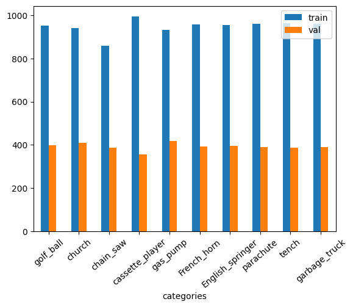

```python
# Representació gràfica de la distribució de classes
import pandas as pd
df = pd.DataFrame(
    {'categories': categories_val,
     'train': num_train,
     'val': num_val
    })
ax = df.plot(x="categories", y=["train", "val"], kind="bar", rot=40)
```

```python
sum(num_train)/(sum(num_train)+sum(num_val))
```

```
0.7069583395550246
```

**Comentaris:**

- **Quin percentatge de les imatges totals correspon a cada conjunt (train/val)?** Train tenim un 70,7% dels valors i la resta a validacio
- **Segons els diagrames de barres, podem afirmar que la distribució per classes és similar en els dos conjunts?**Veiem que si que respectivament cada clase te mes o meny la mateixa distribucio entre train i val
- **Pel que fa al nombre d’imatges per classe, les classes estan equilibrades o hi ha desequilibris notables?**Si mirem la grafica veiem que totes les clases estan en el mateix ordre

### 1.2. Visualització d’imatges.

Ara examinarem el format de les imatges per entendre la seva mida i el seu rang de valors. Visualitzarem algunes imatges d’exemple de cada classe.

**Exercici 1.2 [0,5 pts]:** Mostra com a exemple una imatge per a cada categoria del conjunt d'entrenament. A continuació, respon:

- Tenen totes les imatges les mateixes dimensions (alçada × amplada)?
- Quin és el rang dinàmic dels píxels (valors mínim i màxim) a les imatges?
- Aquests valors són adequats per entrenar una xarxa neuronal?
- Quines accions de pre-processament serien necessàries en relació a la pregunta anterior?

**Nota: es valorarà la concisió en la resposta a les preguntes (una o dues frases són suficients per a cadascuna de les respostes).**

```
JPEG (320, 480) RGB
```

[figure not shown]

```python
import random
from PIL import Image
categori = random.choice(categories_val)
photo = random.choice(os.listdir(path + "/train/" + categori))
im = Image.open(path + "/train/" + categori + "/" + photo)
print(im.format, im.size, im.mode)
display(im)
```

```python
im.size[0]
```

```
320
```

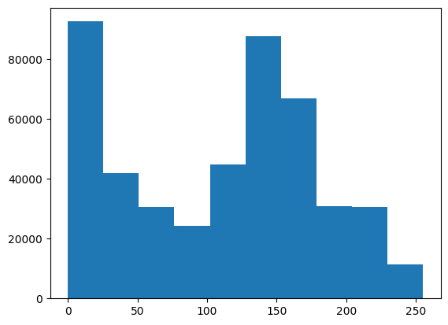

```
0
```

```python
data = np.asarray(im)
a = np.histogram(data ,bins = 255)
plt.hist(data.flatten(order='C'))
plt.show()
data.min()
```

```python
states = os.listdir(path)
height = []
length = []
maximum = []
minimum = []
total = np.zeros(255)
for i in states:
    cat = os.listdir(path + "/" + i)
    for j in cat:
        imgs = os.listdir(path + "/" + i + "/" + j)
        for t in imgs:
            im = Image.open(path + "/" + i + "/" + j + "/" + t)
            height.append(im.size[0])
            length.append(im.size[1])
            data = np.asarray(im)
            minimum.append(data.min())
            maximum.append(data.max())
            #a = np.histogram(data ,bins = 255)
            #total += a[0]
```

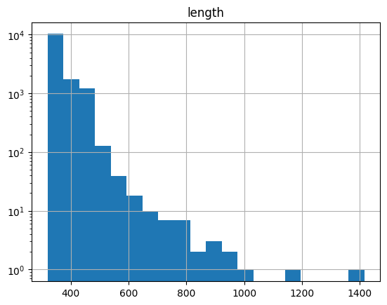

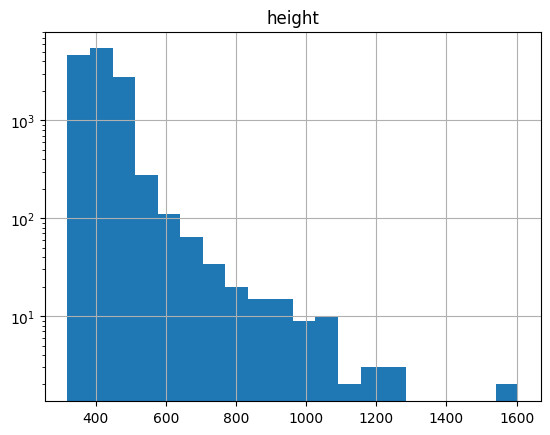

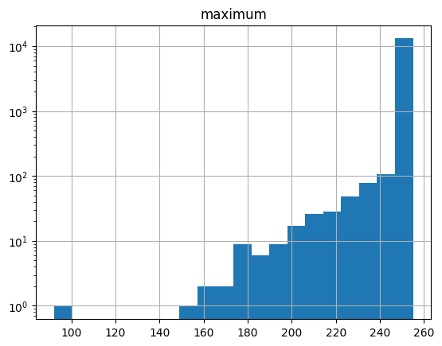

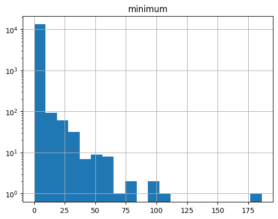

```python
import pandas as pd
df = pd.DataFrame(
    {
        'length': length,
        'height': height,
        'maximum': maximum,
        'minimum': minimum,
    })
df.hist("length",bins=20, log=True)
plt.show()
df.hist("height",bins=20, log=True)
plt.show()
df.hist("maximum",bins=20, log=True)
plt.show()
df.hist("minimum",bins=20, log=True)
plt.show()
```

**Comentaris:**

- **Mida** : Veiem que la mida no es consisten, i que encara que esta acomulada en un punt hi ha variacio.
- **Rang dinàmic** : en la majoria de casos el minim es 0 o prop i el maxim es 255 o aprop aixo es degut a que aquest son els rangs usuals de un valor RGB
- **Adequació per a la xarxa** : El problema mes gran es que per entrenar una xarxa neuronal totes les imatges han de tenir el mateix tamany i clarament no el tenen, depres en el rang dinàmic veiem que hi ha maxims que són mes petits que minims aixó pot ser un problema al extreure caracteristiques perque un podria considerarse que es el mes baix i l'altre el mes alt i tenen valors numerics similars
- **Accions necessàries** : Hauriem de canviar el tamany de totes les imatges perque fos consistent i també podriem normalitzar els valor de cada imatge per no tindre aquesta variabilitat al rang dinamic

### 1.3. Creació dels conjunts de dades en format Keras/TensorFlow

A continuació, prepararem les dades per a l'entrenament amb Keras. Utilitzarem la funció `**tf.keras.utils.image_dataset_from_directory()**` de TensorFlow/Keras, que permet crear lots de dades etiquetats en funció dels directoris d'imatges organitzats per classe.

La documentació d'aquesta funció es troba tant al lloc web de [Keras](https://keras.io/api/data_loading/image/) com al de [TensorFlow](https://www.tensorflow.org/api_docs/python/tf/keras/utils/image_dataset_from_directory).

Aquesta funció ens facilitarà generar conjunts d'entrenament, validació i prova a partir de les carpetes analitzades. Les imatges es re-dimensionaran a una mida fixa i s’organitzaran en lots (batch).

**Especificacions**: convertirem les imatges a la mida de 160 × 160 píxels i les agruparem en lots de 64 imatges. També separarem part de les dades de prova a partir de les de validació.

**Exercici 1.3 [0,5 pts]:** Utilitzeu la funció `tf.keras.utils.image_dataset_from_directory ()` per generar 3 conjunts de dades a partir de les carpetes `/train` i `/val`:

- **train_ds**: Conjunt d'entrenament a partir de `/train/`. Redimensiona les imatges a 160×160, amb `batch_size=64` i `label_mode="categorical"` (10 categories).
- **val_ds**: Conjunt de validació a partir del directori `/val/`, amb un `validation_split` de 0.5 usant `subset="validation"` a la funció i fixa un `seed` per a reproducibilitat. De nou redimensiona les imatges a 160x160 amb `batch_size=64` i `label_mode="categorical"`.
- **test_ds**: Conjunt de test a partir del mateix directori `/val/` usant `subset="training"` a la funció (amb el mateix `seed` per obtenir la partició complementària). Redimensiona també a 160×160 amb `batch_size=64` i fes servir `label_mode="categorical"`.

**NOTA**: l'assignació de `subset="validation"` i `subset="training"` és completament arbitrària i podria haver-se fet al revés. L'important és dividir les dades que es troben a la carpeta `/val` al 50% entre validació i test.  
Comproveu que la base de dades s'ha creat correctament imprimint per pantalla els noms de les classes i les dimensions de cada conjunt de dades. Respon les preguntes següents:

- Quin percentatge aproximat de les imatges s'utilitza a cadascun dels 3 conjunts?
- Quins altres percentatges se solen utilitzar?

**NOTA: Es valorarà la concisió en la resposta a les preguntes (una o dues frases són suficients per cadascuna de les respostes).**

```python
img_height, img_width = 160, 160
batch_size = 64
train_dir = path + "/train/"
# Conjunt d'entrenament
train_dataset = tf.keras.utils.image_dataset_from_directory(train_dir,
                                                            shuffle=True,
                                                            label_mode='categorical',
                                                            seed=123,
                                                            batch_size=batch_size,
                                                            image_size=(img_height, img_width ))
```

```
Found 9469 files belonging to 10 classes.
```

```python
# Conjunt de validació i test (usem el directori de validació d'Imagenette també per a test)
val_test_dir = path + "/val/"

test_dataset = tf.keras.utils.image_dataset_from_directory(val_test_dir,
                                                            shuffle=True,
                                                            label_mode='categorical',
                                                            seed=123,
                                                            validation_split = 0.5,
                                                            subset="training",
                                                            batch_size=batch_size,
                                                            image_size=(img_height, img_width ))
val_dataset = tf.keras.utils.image_dataset_from_directory(val_test_dir,
                                                            shuffle=True,
                                                            label_mode='categorical',
                                                            seed=123,
                                                            validation_split = 0.5,
                                                            subset="validation",
                                                            batch_size=batch_size,
                                                            image_size=(img_height, img_width ))
```

```
Found 3925 files belonging to 10 classes.
Using 1963 files for training.
Found 3925 files belonging to 10 classes.
Using 1962 files for validation.
```

```python
class_names = train_dataset.class_names
print(class_names)
```

```
['English_springer', 'French_horn', 'cassette_player', 'chain_saw', 'church', 'garbage_truck', 'gas_pump', 'golf_ball', 'parachute', 'tench']
```

**Comentaris:**  
El percentatge amb les que entrenarem seran 70 % amb 15% per test i 15% per validar L'estàndard aproximat per a les divisions entrenament, validació, prova és un 60-80% de dades d'entrenament, un 10-20% de dades de validació i un 10-20% de dades de prova

## 2. Xarxa neuronal artificial (ANN) completament connectada (1,5 pts)

Com a primer model, entrenarem una xarxa neuronal **completament connectada** (xarxa densa o Multilayer Perceptron) per **classificar les imatges**. Això servirà de model de referència (línia de base). Atès que la gestió d’imatges de 160×160 píxels directament amb capes denses donaria lloc a vectors d’entrada molt grans i, per tant, un gran nombre de paràmetres, primer aplicarem una reducció de la dimensionalitat de les imatges d’entrada. Concretament, reduirem cada imatge a 32×32 píxels (mitjançant una capa de redimensionat) abans d’aplanar-la, que simplificarà el model.

**Arquitectura proposada**: Utilitzarem l’API funcional de Keras (classe Model) per construir la xarxa. Utilitzarem les capes Resizing i Rescaling de Keras per preparar les imatges, seguides de Flatten per aplanar-les, i diverses capes Dense intercalades amb Dropout pel classificador.

En aquesta secció utilitzarem les capes [Resizing](https://keras.io/api/layers/preprocessing_layers/image_preprocessing/resizing/), [Rescaling](https://keras.io/api/layers/preprocessing_layers/image_preprocessing/rescaling/), [Flatten](https://keras.io/api/layers/reshaping_layers/flatten/), [Dense](https://keras.io/api/layers/core_layers/dense/) i [Dropout](https://keras.io/api/layers/regularization_layers/dropout/) de Keras.

**Exercici 2.1 [0,5 pts]:** Implementa un model **funcional** de Keras amb les següents característiques:

- Una capa que redueixi les dimensions d'entrada de (160,160) a (32,32).
- Una capa de reescalat perquè els valors de píxel quedin entre 0 i 1.
- Una capa Flatten per convertir la imatge reduïda en un vector 1D.
- Una capa densa completament connectada que tingui un nombre de neurones equivalent a dos terços de la mida de la capa anterior, activació ReLU.
- Una capa Dropout amb probabilitat 0.5.
- Una altra capa densa de la meitat de la mida que la capa densa inmediatament anterior, activació ReLU.
- Una altra capa Dropout amb probabilitat 0.5.
- Una capa de sortida densa amb la mida i la funció d'activació adequades per al problema de classificació que es planteja.

**Nota: Visualitzar els models de tots els exercicis amb la funció `summary()`**  
Contestar les preguntes següents:

- Quina mida hauria de tenir la capa d'entrada si haguéssim treballat amb les imatges de la base de dades directament de 160x160 píxels?
- Quina reducció s'aconsegueix en reescalar les imatges a 32x32 píxels?
- Quants paràmetres té el model?

**NOTA: Es valorarà la concisió en la resposta a les preguntes (una o dues frases són suficients per a cadascuna de les respostes).**

```python
# Construcció del model ANN completament connectat (model funcional)

model = keras.Sequential()
model.add(keras.layers.InputLayer(shape=(160, 160, 3)))
model.add(keras.layers.Resizing(32, 32))
model.add(keras.layers.Rescaling(scale=1./255.))
model.add(keras.layers.Flatten())
model.add(keras.layers.Dense(int(3072*2/3), activation='relu'))
model.add(keras.layers.Dropout(0.5))
model.add(keras.layers.Dense(int(2048/2), activation='relu'))
model.add(keras.layers.Dropout(0.5))
model.add(keras.layers.Dense(10, activation='sigmoid'))

model.summary()
```

```
Model: "sequential"
```

```
┏━━━━━━━━━━━━━━━━━━━━━━━━━━━━━━━━━━━━━━┳━━━━━━━━━━━━━━━━━━━━━━━━━━━━━┳━━━━━━━━━━━━━━━━━┓
┃ Layer (type)                         ┃ Output Shape                ┃         Param # ┃
┡━━━━━━━━━━━━━━━━━━━━━━━━━━━━━━━━━━━━━━╇━━━━━━━━━━━━━━━━━━━━━━━━━━━━━╇━━━━━━━━━━━━━━━━━┩
│ resizing (Resizing)                  │ (None, 32, 32, 3)           │               0 │
├──────────────────────────────────────┼─────────────────────────────┼─────────────────┤
│ rescaling (Rescaling)                │ (None, 32, 32, 3)           │               0 │
├──────────────────────────────────────┼─────────────────────────────┼─────────────────┤
│ flatten (Flatten)                    │ (None, 3072)                │               0 │
├──────────────────────────────────────┼─────────────────────────────┼─────────────────┤
│ dense (Dense)                        │ (None, 2048)                │       6,293,504 │
├──────────────────────────────────────┼─────────────────────────────┼─────────────────┤
│ dropout (Dropout)                    │ (None, 2048)                │               0 │
├──────────────────────────────────────┼─────────────────────────────┼─────────────────┤
│ dense_1 (Dense)                      │ (None, 1024)                │       2,098,176 │
├──────────────────────────────────────┼─────────────────────────────┼─────────────────┤
│ dropout_1 (Dropout)                  │ (None, 1024)                │               0 │
├──────────────────────────────────────┼─────────────────────────────┼─────────────────┤
│ dense_2 (Dense)                      │ (None, 10)                  │          10,250 │
└──────────────────────────────────────┴─────────────────────────────┴─────────────────┘
```

```
 Total params: 8,401,930 (32.05 MB)
```

```
 Trainable params: 8,401,930 (32.05 MB)
```

```
 Non-trainable params: 0 (0.00 B)
```

Procedim a compilar i entrenar el model:

**Exercici 2.2 [1 PTS]:** Quan entreneu qualsevol model, és essencial fer una bona elecció dels hiperparameters. En aquest exercici compilarem i entrenarem el model creat analitzant els efectes del *learning rate* en l'entrenament. Concretament, provarem els valors de 1e-3, 1e-4 i 1e-5. Per a cada valor de *learning rate* es demana:

- Compileu el model amb l'optimitzador **Adam** i el corresponent *learning rate*.
- Entrena el model durant **100 epochs**, mitjançant:
  - *EarlyStopping* monitoritzant la pèrdua (*loss*) en validació, amb paciència de 10 epochs, restablint els millors pesos obtinguts.
  - *ReduceLROnPlateau* monitoritzant la pèrdua (*loss*) en validació, factor 0,2, paciència de 5 epochs i un *learning rate* mínim de 1e-6
  - La mètrica de rendiment *accuracy* tant en entrenament com en validació.
- Gràfic de de les corbes de *accuracy* i *loss* per als conjunts d'entrenament i validació.
- Finalment, avalueu el model entrenat al conjunt de test, mostrant la pèrdua (*loss*) i la precisió (*accuracy*) obtingudes en aquestes dades.

Feu una comparació de l'efecte del *learning rate* en els 3 entrenaments basada en:

- Número d’èpoques/temps d’entrenament.
- Forma de les corbes d’entrenament.
- Rendiment del model al conjunt de prova (test).
- Quina taxa d’aprenentatge seleccionaries en funció del que s'ha comentat en els punts anteriors?

**Nota: es valorarà la concisió a les preguntes (una o dues frases són suficients per a cadascuna de les respostes).**

Comencem amb lr = 1e-3

```python
# Compilació del model

model.compile(optimizer=keras.optimizers.Adam(learning_rate=1e-3), loss=keras.losses.CategoricalCrossentropy(),metrics=['accuracy'], )
```

```python
# Definir callbacks: EarlyStopping
callback = keras.callbacks.EarlyStopping(monitor='loss', patience=10)
reduce_lr = ReduceLROnPlateau(monitor='val_loss', factor=0.2, patience=5, min_lr=1e-6)
# Entrenament del model
history = model.fit(train_dataset, epochs=100,
                    validation_data=(test_dataset),callbacks=[reduce_lr,callback])
```

```
148/148 ━━━━━━━━━━━━━━━━━━━━ 24s 146ms/step - accuracy: 0.2180 - loss: 4.5413 - val_accuracy: 0.3082 - val_loss: 1.9971 - learning_rate: 0.0010
148/148 ━━━━━━━━━━━━━━━━━━━━ 16s 107ms/step - accuracy: 0.2774 - loss: 2.0331 - val_accuracy: 0.3439 - val_loss: 1.9320 - learning_rate: 0.0010
148/148 ━━━━━━━━━━━━━━━━━━━━ 17s 113ms/step - accuracy: 0.2888 - loss: 2.0168 - val_accuracy: 0.3505 - val_loss: 1.9610 - learning_rate: 0.0010
148/148 ━━━━━━━━━━━━━━━━━━━━ 18s 119ms/step - accuracy: 0.2855 - loss: 2.0006 - val_accuracy: 0.3260 - val_loss: 1.9735 - learning_rate: 0.0010
148/148 ━━━━━━━━━━━━━━━━━━━━ 18s 121ms/step - accuracy: 0.2790 - loss: 2.0241 - val_accuracy: 0.3540 - val_loss: 1.9142 - learning_rate: 0.0010
148/148 ━━━━━━━━━━━━━━━━━━━━ 19s 128ms/step - accuracy: 0.3054 - loss: 1.9726 - val_accuracy: 0.3872 - val_loss: 1.8756 - learning_rate: 0.0010
148/148 ━━━━━━━━━━━━━━━━━━━━ 18s 122ms/step - accuracy: 0.3050 - loss: 1.9605 - val_accuracy: 0.3647 - val_loss: 1.8930 - learning_rate: 0.0010
148/148 ━━━━━━━━━━━━━━━━━━━━ 19s 126ms/step - accuracy: 0.3185 - loss: 1.9332 - val_accuracy: 0.3612 - val_loss: 1.9126 - learning_rate: 0.0010
148/148 ━━━━━━━━━━━━━━━━━━━━ 19s 127ms/step - accuracy: 0.3039 - loss: 1.9445 - val_accuracy: 0.3851 - val_loss: 1.8781 - learning_rate: 0.0010
148/148 ━━━━━━━━━━━━━━━━━━━━ 18s 124ms/step - accuracy: 0.3127 - loss: 1.9319 - val_accuracy: 0.3484 - val_loss: 1.9184 - learning_rate: 0.0010
148/148 ━━━━━━━━━━━━━━━━━━━━ 14s 92ms/step - accuracy: 0.3149 - loss: 1.9265 - val_accuracy: 0.3576 - val_loss: 1.9090 - learning_rate: 0.0010
148/148 ━━━━━━━━━━━━━━━━━━━━ 6s 43ms/step - accuracy: 0.3560 - loss: 1.8499 - val_accuracy: 0.4014 - val_loss: 1.8235 - learning_rate: 2.0000e-04
148/148 ━━━━━━━━━━━━━━━━━━━━ 6s 42ms/step - accuracy: 0.3758 - loss: 1.7940 - val_accuracy: 0.3948 - val_loss: 1.8098 - learning_rate: 2.0000e-04
148/148 ━━━━━━━━━━━━━━━━━━━━ 6s 43ms/step - accuracy: 0.3748 - loss: 1.7922 - val_accuracy: 0.4075 - val_loss: 1.7965 - learning_rate: 2.0000e-04
148/148 ━━━━━━━━━━━━━━━━━━━━ 6s 42ms/step - accuracy: 0.3761 - loss: 1.7583 - val_accuracy: 0.4086 - val_loss: 1.7980 - learning_rate: 2.0000e-04
148/148 ━━━━━━━━━━━━━━━━━━━━ 6s 43ms/step - accuracy: 0.3994 - loss: 1.7619 - val_accuracy: 0.4126 - val_loss: 1.7885 - learning_rate: 2.0000e-04
148/148 ━━━━━━━━━━━━━━━━━━━━ 6s 43ms/step - accuracy: 0.3954 - loss: 1.7424 - val_accuracy: 0.4065 - val_loss: 1.7955 - learning_rate: 2.0000e-04
148/148 ━━━━━━━━━━━━━━━━━━━━ 6s 41ms/step - accuracy: 0.3936 - loss: 1.7384 - val_accuracy: 0.4193 - val_loss: 1.7826 - learning_rate: 2.0000e-04
148/148 ━━━━━━━━━━━━━━━━━━━━ 6s 42ms/step - accuracy: 0.4061 - loss: 1.7271 - val_accuracy: 0.4198 - val_loss: 1.7647 - learning_rate: 2.0000e-04
148/148 ━━━━━━━━━━━━━━━━━━━━ 6s 41ms/step - accuracy: 0.4076 - loss: 1.7153 - val_accuracy: 0.4203 - val_loss: 1.7646 - learning_rate: 2.0000e-04
148/148 ━━━━━━━━━━━━━━━━━━━━ 6s 41ms/step - accuracy: 0.4021 - loss: 1.7100 - val_accuracy: 0.4111 - val_loss: 1.7607 - learning_rate: 2.0000e-04
148/148 ━━━━━━━━━━━━━━━━━━━━ 7s 45ms/step - accuracy: 0.4116 - loss: 1.7054 - val_accuracy: 0.4274 - val_loss: 1.7616 - learning_rate: 2.0000e-04
148/148 ━━━━━━━━━━━━━━━━━━━━ 6s 42ms/step - accuracy: 0.4146 - loss: 1.6821 - val_accuracy: 0.4208 - val_loss: 1.7529 - learning_rate: 2.0000e-04
148/148 ━━━━━━━━━━━━━━━━━━━━ 6s 42ms/step - accuracy: 0.4211 - loss: 1.6788 - val_accuracy: 0.4249 - val_loss: 1.7429 - learning_rate: 2.0000e-04
148/148 ━━━━━━━━━━━━━━━━━━━━ 6s 41ms/step - accuracy: 0.4275 - loss: 1.6554 - val_accuracy: 0.4142 - val_loss: 1.7619 - learning_rate: 2.0000e-04
148/148 ━━━━━━━━━━━━━━━━━━━━ 6s 41ms/step - accuracy: 0.4232 - loss: 1.6628 - val_accuracy: 0.4233 - val_loss: 1.7468 - learning_rate: 2.0000e-04
148/148 ━━━━━━━━━━━━━━━━━━━━ 6s 43ms/step - accuracy: 0.4320 - loss: 1.6566 - val_accuracy: 0.4269 - val_loss: 1.7353 - learning_rate: 2.0000e-04
148/148 ━━━━━━━━━━━━━━━━━━━━ 6s 43ms/step - accuracy: 0.4367 - loss: 1.6264 - val_accuracy: 0.4264 - val_loss: 1.7333 - learning_rate: 2.0000e-04
148/148 ━━━━━━━━━━━━━━━━━━━━ 6s 43ms/step - accuracy: 0.4386 - loss: 1.6284 - val_accuracy: 0.4350 - val_loss: 1.7255 - learning_rate: 2.0000e-04
148/148 ━━━━━━━━━━━━━━━━━━━━ 6s 42ms/step - accuracy: 0.4469 - loss: 1.6016 - val_accuracy: 0.4254 - val_loss: 1.7327 - learning_rate: 2.0000e-04
148/148 ━━━━━━━━━━━━━━━━━━━━ 6s 42ms/step - accuracy: 0.4462 - loss: 1.6067 - val_accuracy: 0.4238 - val_loss: 1.7426 - learning_rate: 2.0000e-04
148/148 ━━━━━━━━━━━━━━━━━━━━ 7s 45ms/step - accuracy: 0.4614 - loss: 1.5765 - val_accuracy: 0.4335 - val_loss: 1.7185 - learning_rate: 2.0000e-04
148/148 ━━━━━━━━━━━━━━━━━━━━ 6s 43ms/step - accuracy: 0.4569 - loss: 1.5747 - val_accuracy: 0.4330 - val_loss: 1.7067 - learning_rate: 2.0000e-04
148/148 ━━━━━━━━━━━━━━━━━━━━ 6s 42ms/step - accuracy: 0.4510 - loss: 1.5802 - val_accuracy: 0.4315 - val_loss: 1.7248 - learning_rate: 2.0000e-04
148/148 ━━━━━━━━━━━━━━━━━━━━ 6s 43ms/step - accuracy: 0.4628 - loss: 1.5627 - val_accuracy: 0.4386 - val_loss: 1.6991 - learning_rate: 2.0000e-04
148/148 ━━━━━━━━━━━━━━━━━━━━ 6s 42ms/step - accuracy: 0.4581 - loss: 1.5622 - val_accuracy: 0.4340 - val_loss: 1.7118 - learning_rate: 2.0000e-04
148/148 ━━━━━━━━━━━━━━━━━━━━ 6s 44ms/step - accuracy: 0.4655 - loss: 1.5513 - val_accuracy: 0.4401 - val_loss: 1.6985 - learning_rate: 2.0000e-04
148/148 ━━━━━━━━━━━━━━━━━━━━ 6s 42ms/step - accuracy: 0.4720 - loss: 1.5225 - val_accuracy: 0.4325 - val_loss: 1.7153 - learning_rate: 2.0000e-04
148/148 ━━━━━━━━━━━━━━━━━━━━ 6s 42ms/step - accuracy: 0.4683 - loss: 1.5562 - val_accuracy: 0.4391 - val_loss: 1.7204 - learning_rate: 2.0000e-04
148/148 ━━━━━━━━━━━━━━━━━━━━ 6s 41ms/step - accuracy: 0.4779 - loss: 1.5179 - val_accuracy: 0.4259 - val_loss: 1.7076 - learning_rate: 2.0000e-04
```

[output cut: 38 more lines]

```
148/148 ━━━━━━━━━━━━━━━━━━━━ 7s 46ms/step - accuracy: 0.5457 - loss: 1.3161 - val_accuracy: 0.4376 - val_loss: 1.6826 - learning_rate: 1.0000e-06
148/148 ━━━━━━━━━━━━━━━━━━━━ 6s 43ms/step - accuracy: 0.5536 - loss: 1.2874 - val_accuracy: 0.4376 - val_loss: 1.6827 - learning_rate: 1.0000e-06
148/148 ━━━━━━━━━━━━━━━━━━━━ 7s 46ms/step - accuracy: 0.5560 - loss: 1.2985 - val_accuracy: 0.4371 - val_loss: 1.6836 - learning_rate: 1.0000e-06
148/148 ━━━━━━━━━━━━━━━━━━━━ 6s 42ms/step - accuracy: 0.5529 - loss: 1.3133 - val_accuracy: 0.4366 - val_loss: 1.6834 - learning_rate: 1.0000e-06
148/148 ━━━━━━━━━━━━━━━━━━━━ 6s 42ms/step - accuracy: 0.5588 - loss: 1.2935 - val_accuracy: 0.4381 - val_loss: 1.6832 - learning_rate: 1.0000e-06
148/148 ━━━━━━━━━━━━━━━━━━━━ 6s 43ms/step - accuracy: 0.5518 - loss: 1.3089 - val_accuracy: 0.4391 - val_loss: 1.6831 - learning_rate: 1.0000e-06
148/148 ━━━━━━━━━━━━━━━━━━━━ 6s 42ms/step - accuracy: 0.5503 - loss: 1.3056 - val_accuracy: 0.4386 - val_loss: 1.6829 - learning_rate: 1.0000e-06
148/148 ━━━━━━━━━━━━━━━━━━━━ 7s 44ms/step - accuracy: 0.5595 - loss: 1.3005 - val_accuracy: 0.4381 - val_loss: 1.6830 - learning_rate: 1.0000e-06
148/148 ━━━━━━━━━━━━━━━━━━━━ 6s 43ms/step - accuracy: 0.5626 - loss: 1.2967 - val_accuracy: 0.4386 - val_loss: 1.6832 - learning_rate: 1.0000e-06
148/148 ━━━━━━━━━━━━━━━━━━━━ 6s 42ms/step - accuracy: 0.5531 - loss: 1.3019 - val_accuracy: 0.4396 - val_loss: 1.6831 - learning_rate: 1.0000e-06
148/148 ━━━━━━━━━━━━━━━━━━━━ 7s 44ms/step - accuracy: 0.5569 - loss: 1.3004 - val_accuracy: 0.4401 - val_loss: 1.6824 - learning_rate: 1.0000e-06
148/148 ━━━━━━━━━━━━━━━━━━━━ 6s 43ms/step - accuracy: 0.5552 - loss: 1.3062 - val_accuracy: 0.4407 - val_loss: 1.6827 - learning_rate: 1.0000e-06
148/148 ━━━━━━━━━━━━━━━━━━━━ 7s 45ms/step - accuracy: 0.5617 - loss: 1.2843 - val_accuracy: 0.4396 - val_loss: 1.6827 - learning_rate: 1.0000e-06
148/148 ━━━━━━━━━━━━━━━━━━━━ 6s 41ms/step - accuracy: 0.5610 - loss: 1.3037 - val_accuracy: 0.4407 - val_loss: 1.6827 - learning_rate: 1.0000e-06
148/148 ━━━━━━━━━━━━━━━━━━━━ 6s 42ms/step - accuracy: 0.5573 - loss: 1.2987 - val_accuracy: 0.4391 - val_loss: 1.6834 - learning_rate: 1.0000e-06
```

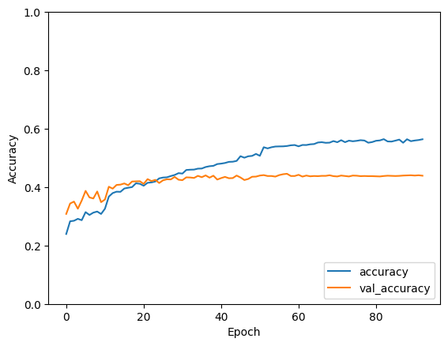

```python
# Funció auxiliar per graficar accuracy i loss
plt.plot(history.history['accuracy'], label='accuracy')
plt.plot(history.history['val_accuracy'], label = 'val_accuracy')
plt.xlabel('Epoch')
plt.ylabel('Accuracy')
plt.ylim([0.0, 1])
plt.legend(loc='lower right')
```

```python
# Validació al conjunt de prova
test_loss, test_acc = model.evaluate(val_dataset, verbose=2)
```

```
31/31 - 2s - 61ms/step - accuracy: 0.4521 - loss: 1.6772
```

Repetim amb lr = 1e-4

```
148/148 ━━━━━━━━━━━━━━━━━━━━ 10s 54ms/step - accuracy: 0.1729 - loss: 2.3320 - val_accuracy: 0.3128 - val_loss: 2.0051 - learning_rate: 1.0000e-04
148/148 ━━━━━━━━━━━━━━━━━━━━ 12s 79ms/step - accuracy: 0.2756 - loss: 2.0468 - val_accuracy: 0.3449 - val_loss: 1.9428 - learning_rate: 1.0000e-04
148/148 ━━━━━━━━━━━━━━━━━━━━ 7s 44ms/step - accuracy: 0.3087 - loss: 1.9849 - val_accuracy: 0.3510 - val_loss: 1.9001 - learning_rate: 1.0000e-04
148/148 ━━━━━━━━━━━━━━━━━━━━ 8s 54ms/step - accuracy: 0.3302 - loss: 1.9266 - val_accuracy: 0.3428 - val_loss: 1.8967 - learning_rate: 1.0000e-04
148/148 ━━━━━━━━━━━━━━━━━━━━ 7s 46ms/step - accuracy: 0.3348 - loss: 1.9085 - val_accuracy: 0.3688 - val_loss: 1.8424 - learning_rate: 1.0000e-04
148/148 ━━━━━━━━━━━━━━━━━━━━ 6s 43ms/step - accuracy: 0.3593 - loss: 1.8524 - val_accuracy: 0.3831 - val_loss: 1.8017 - learning_rate: 1.0000e-04
148/148 ━━━━━━━━━━━━━━━━━━━━ 6s 43ms/step - accuracy: 0.3753 - loss: 1.8149 - val_accuracy: 0.4030 - val_loss: 1.7791 - learning_rate: 1.0000e-04
148/148 ━━━━━━━━━━━━━━━━━━━━ 6s 42ms/step - accuracy: 0.3895 - loss: 1.7945 - val_accuracy: 0.3999 - val_loss: 1.7768 - learning_rate: 1.0000e-04
148/148 ━━━━━━━━━━━━━━━━━━━━ 7s 45ms/step - accuracy: 0.3974 - loss: 1.7625 - val_accuracy: 0.4147 - val_loss: 1.7485 - learning_rate: 1.0000e-04
148/148 ━━━━━━━━━━━━━━━━━━━━ 7s 45ms/step - accuracy: 0.4113 - loss: 1.7350 - val_accuracy: 0.4131 - val_loss: 1.7412 - learning_rate: 1.0000e-04
148/148 ━━━━━━━━━━━━━━━━━━━━ 8s 51ms/step - accuracy: 0.4233 - loss: 1.6968 - val_accuracy: 0.4126 - val_loss: 1.7347 - learning_rate: 1.0000e-04
148/148 ━━━━━━━━━━━━━━━━━━━━ 6s 42ms/step - accuracy: 0.4342 - loss: 1.6769 - val_accuracy: 0.4320 - val_loss: 1.6938 - learning_rate: 1.0000e-04
148/148 ━━━━━━━━━━━━━━━━━━━━ 6s 43ms/step - accuracy: 0.4413 - loss: 1.6674 - val_accuracy: 0.4300 - val_loss: 1.6816 - learning_rate: 1.0000e-04
148/148 ━━━━━━━━━━━━━━━━━━━━ 7s 45ms/step - accuracy: 0.4453 - loss: 1.6461 - val_accuracy: 0.4412 - val_loss: 1.6785 - learning_rate: 1.0000e-04
148/148 ━━━━━━━━━━━━━━━━━━━━ 7s 45ms/step - accuracy: 0.4503 - loss: 1.6277 - val_accuracy: 0.4503 - val_loss: 1.6566 - learning_rate: 1.0000e-04
148/148 ━━━━━━━━━━━━━━━━━━━━ 8s 52ms/step - accuracy: 0.4576 - loss: 1.6059 - val_accuracy: 0.4412 - val_loss: 1.6644 - learning_rate: 1.0000e-04
148/148 ━━━━━━━━━━━━━━━━━━━━ 6s 42ms/step - accuracy: 0.4792 - loss: 1.5599 - val_accuracy: 0.4366 - val_loss: 1.6503 - learning_rate: 1.0000e-04
148/148 ━━━━━━━━━━━━━━━━━━━━ 6s 41ms/step - accuracy: 0.4776 - loss: 1.5414 - val_accuracy: 0.4396 - val_loss: 1.6635 - learning_rate: 1.0000e-04
148/148 ━━━━━━━━━━━━━━━━━━━━ 6s 44ms/step - accuracy: 0.4933 - loss: 1.5187 - val_accuracy: 0.4422 - val_loss: 1.6542 - learning_rate: 1.0000e-04
148/148 ━━━━━━━━━━━━━━━━━━━━ 6s 42ms/step - accuracy: 0.4884 - loss: 1.4968 - val_accuracy: 0.4513 - val_loss: 1.6344 - learning_rate: 1.0000e-04
148/148 ━━━━━━━━━━━━━━━━━━━━ 7s 45ms/step - accuracy: 0.5105 - loss: 1.4825 - val_accuracy: 0.4610 - val_loss: 1.6256 - learning_rate: 1.0000e-04
148/148 ━━━━━━━━━━━━━━━━━━━━ 7s 51ms/step - accuracy: 0.5144 - loss: 1.4439 - val_accuracy: 0.4554 - val_loss: 1.6280 - learning_rate: 1.0000e-04
148/148 ━━━━━━━━━━━━━━━━━━━━ 10s 70ms/step - accuracy: 0.5270 - loss: 1.4214 - val_accuracy: 0.4631 - val_loss: 1.6198 - learning_rate: 1.0000e-04
148/148 ━━━━━━━━━━━━━━━━━━━━ 8s 53ms/step - accuracy: 0.5223 - loss: 1.3970 - val_accuracy: 0.4508 - val_loss: 1.6530 - learning_rate: 1.0000e-04
148/148 ━━━━━━━━━━━━━━━━━━━━ 6s 41ms/step - accuracy: 0.5418 - loss: 1.3845 - val_accuracy: 0.4508 - val_loss: 1.6187 - learning_rate: 1.0000e-04
148/148 ━━━━━━━━━━━━━━━━━━━━ 6s 41ms/step - accuracy: 0.5482 - loss: 1.3551 - val_accuracy: 0.4590 - val_loss: 1.6215 - learning_rate: 1.0000e-04
148/148 ━━━━━━━━━━━━━━━━━━━━ 6s 41ms/step - accuracy: 0.5588 - loss: 1.3303 - val_accuracy: 0.4620 - val_loss: 1.6312 - learning_rate: 1.0000e-04
148/148 ━━━━━━━━━━━━━━━━━━━━ 6s 43ms/step - accuracy: 0.5566 - loss: 1.3216 - val_accuracy: 0.4651 - val_loss: 1.6151 - learning_rate: 1.0000e-04
148/148 ━━━━━━━━━━━━━━━━━━━━ 6s 41ms/step - accuracy: 0.5730 - loss: 1.2847 - val_accuracy: 0.4677 - val_loss: 1.6420 - learning_rate: 1.0000e-04
148/148 ━━━━━━━━━━━━━━━━━━━━ 6s 41ms/step - accuracy: 0.5661 - loss: 1.2600 - val_accuracy: 0.4626 - val_loss: 1.6376 - learning_rate: 1.0000e-04
148/148 ━━━━━━━━━━━━━━━━━━━━ 6s 43ms/step - accuracy: 0.5843 - loss: 1.2350 - val_accuracy: 0.4651 - val_loss: 1.6569 - learning_rate: 1.0000e-04
148/148 ━━━━━━━━━━━━━━━━━━━━ 6s 42ms/step - accuracy: 0.5881 - loss: 1.2241 - val_accuracy: 0.4585 - val_loss: 1.6616 - learning_rate: 1.0000e-04
148/148 ━━━━━━━━━━━━━━━━━━━━ 7s 44ms/step - accuracy: 0.5927 - loss: 1.1978 - val_accuracy: 0.4682 - val_loss: 1.6571 - learning_rate: 1.0000e-04
148/148 ━━━━━━━━━━━━━━━━━━━━ 6s 41ms/step - accuracy: 0.6399 - loss: 1.1045 - val_accuracy: 0.4748 - val_loss: 1.6373 - learning_rate: 2.0000e-05
148/148 ━━━━━━━━━━━━━━━━━━━━ 6s 42ms/step - accuracy: 0.6588 - loss: 1.0456 - val_accuracy: 0.4753 - val_loss: 1.6372 - learning_rate: 2.0000e-05
148/148 ━━━━━━━━━━━━━━━━━━━━ 6s 40ms/step - accuracy: 0.6626 - loss: 1.0373 - val_accuracy: 0.4738 - val_loss: 1.6440 - learning_rate: 2.0000e-05
148/148 ━━━━━━━━━━━━━━━━━━━━ 6s 40ms/step - accuracy: 0.6661 - loss: 1.0223 - val_accuracy: 0.4845 - val_loss: 1.6445 - learning_rate: 2.0000e-05
148/148 ━━━━━━━━━━━━━━━━━━━━ 7s 44ms/step - accuracy: 0.6703 - loss: 1.0114 - val_accuracy: 0.4748 - val_loss: 1.6450 - learning_rate: 2.0000e-05
148/148 ━━━━━━━━━━━━━━━━━━━━ 6s 41ms/step - accuracy: 0.6713 - loss: 1.0059 - val_accuracy: 0.4789 - val_loss: 1.6388 - learning_rate: 4.0000e-06
148/148 ━━━━━━━━━━━━━━━━━━━━ 6s 42ms/step - accuracy: 0.6853 - loss: 0.9767 - val_accuracy: 0.4829 - val_loss: 1.6425 - learning_rate: 4.0000e-06
```

[output cut: 21 more lines]

```
148/148 ━━━━━━━━━━━━━━━━━━━━ 7s 44ms/step - accuracy: 0.6896 - loss: 0.9434 - val_accuracy: 0.4778 - val_loss: 1.6484 - learning_rate: 1.0000e-06
148/148 ━━━━━━━━━━━━━━━━━━━━ 6s 40ms/step - accuracy: 0.7019 - loss: 0.9297 - val_accuracy: 0.4794 - val_loss: 1.6478 - learning_rate: 1.0000e-06
148/148 ━━━━━━━━━━━━━━━━━━━━ 6s 41ms/step - accuracy: 0.7017 - loss: 0.9345 - val_accuracy: 0.4783 - val_loss: 1.6484 - learning_rate: 1.0000e-06
148/148 ━━━━━━━━━━━━━━━━━━━━ 6s 42ms/step - accuracy: 0.7042 - loss: 0.9273 - val_accuracy: 0.4783 - val_loss: 1.6498 - learning_rate: 1.0000e-06
148/148 ━━━━━━━━━━━━━━━━━━━━ 6s 42ms/step - accuracy: 0.6952 - loss: 0.9329 - val_accuracy: 0.4763 - val_loss: 1.6496 - learning_rate: 1.0000e-06
148/148 ━━━━━━━━━━━━━━━━━━━━ 6s 44ms/step - accuracy: 0.6962 - loss: 0.9340 - val_accuracy: 0.4783 - val_loss: 1.6495 - learning_rate: 1.0000e-06
148/148 ━━━━━━━━━━━━━━━━━━━━ 6s 42ms/step - accuracy: 0.7043 - loss: 0.9308 - val_accuracy: 0.4814 - val_loss: 1.6489 - learning_rate: 1.0000e-06
148/148 ━━━━━━━━━━━━━━━━━━━━ 6s 43ms/step - accuracy: 0.6976 - loss: 0.9322 - val_accuracy: 0.4804 - val_loss: 1.6492 - learning_rate: 1.0000e-06
148/148 ━━━━━━━━━━━━━━━━━━━━ 6s 43ms/step - accuracy: 0.7008 - loss: 0.9293 - val_accuracy: 0.4814 - val_loss: 1.6498 - learning_rate: 1.0000e-06
148/148 ━━━━━━━━━━━━━━━━━━━━ 6s 43ms/step - accuracy: 0.7016 - loss: 0.9299 - val_accuracy: 0.4829 - val_loss: 1.6500 - learning_rate: 1.0000e-06
148/148 ━━━━━━━━━━━━━━━━━━━━ 6s 43ms/step - accuracy: 0.7009 - loss: 0.9339 - val_accuracy: 0.4799 - val_loss: 1.6501 - learning_rate: 1.0000e-06
148/148 ━━━━━━━━━━━━━━━━━━━━ 6s 42ms/step - accuracy: 0.6978 - loss: 0.9276 - val_accuracy: 0.4809 - val_loss: 1.6503 - learning_rate: 1.0000e-06
148/148 ━━━━━━━━━━━━━━━━━━━━ 6s 41ms/step - accuracy: 0.7040 - loss: 0.9344 - val_accuracy: 0.4799 - val_loss: 1.6501 - learning_rate: 1.0000e-06
148/148 ━━━━━━━━━━━━━━━━━━━━ 6s 41ms/step - accuracy: 0.6966 - loss: 0.9383 - val_accuracy: 0.4809 - val_loss: 1.6496 - learning_rate: 1.0000e-06
31/31 - 2s - 58ms/step - accuracy: 0.4679 - loss: 1.6427
```

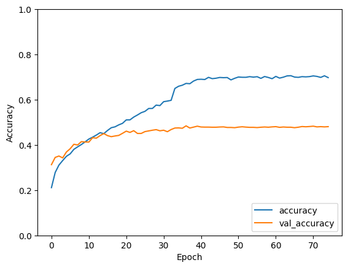

```python
# Crear un nou model sense pesos previs

model = keras.Sequential()
model.add(keras.layers.InputLayer(shape=(160, 160, 3)))
model.add(keras.layers.Resizing(32, 32))
model.add(keras.layers.Rescaling(scale=1./255.))
model.add(keras.layers.Flatten())
model.add(keras.layers.Dense(int(3072*2/3), activation='relu'))
model.add(keras.layers.Dropout(0.5))
model.add(keras.layers.Dense(int(2048/2), activation='relu'))
model.add(keras.layers.Dropout(0.5))
model.add(keras.layers.Dense(10, activation='sigmoid'))



# Compilació del model
model.compile(optimizer=keras.optimizers.Adam(learning_rate=1e-4), loss=keras.losses.CategoricalCrossentropy(),metrics=['accuracy'], )

# Definir callbacks: EarlyStopping
callback = keras.callbacks.EarlyStopping(monitor='loss', patience=10)
reduce_lr = ReduceLROnPlateau(monitor='val_loss', factor=0.2, patience=5, min_lr=1e-6)


# Entrenament del model
history = model.fit(train_dataset, epochs=100,
                    validation_data=(test_dataset),callbacks=[reduce_lr,callback])
plt.plot(history.history['accuracy'], label='accuracy')
plt.plot(history.history['val_accuracy'], label = 'val_accuracy')
plt.xlabel('Epoch')
plt.ylabel('Accuracy')
plt.ylim([0.0, 1])
plt.legend(loc='lower right')

# Validació al conjunt de prova
test_loss, test_acc = model.evaluate(val_dataset, verbose=2)
```

Acabem amb lr = 1e-5

```
148/148 ━━━━━━━━━━━━━━━━━━━━ 10s 53ms/step - accuracy: 0.1274 - loss: 2.4562 - val_accuracy: 0.2552 - val_loss: 2.1200 - learning_rate: 1.0000e-05
148/148 ━━━━━━━━━━━━━━━━━━━━ 7s 46ms/step - accuracy: 0.2020 - loss: 2.2008 - val_accuracy: 0.2980 - val_loss: 2.0384 - learning_rate: 1.0000e-05
148/148 ━━━━━━━━━━━━━━━━━━━━ 8s 51ms/step - accuracy: 0.2569 - loss: 2.0888 - val_accuracy: 0.3118 - val_loss: 1.9919 - learning_rate: 1.0000e-05
148/148 ━━━━━━━━━━━━━━━━━━━━ 6s 41ms/step - accuracy: 0.2790 - loss: 2.0470 - val_accuracy: 0.3337 - val_loss: 1.9597 - learning_rate: 1.0000e-05
148/148 ━━━━━━━━━━━━━━━━━━━━ 6s 41ms/step - accuracy: 0.2933 - loss: 2.0103 - val_accuracy: 0.3388 - val_loss: 1.9334 - learning_rate: 1.0000e-05
148/148 ━━━━━━━━━━━━━━━━━━━━ 6s 41ms/step - accuracy: 0.3120 - loss: 1.9647 - val_accuracy: 0.3428 - val_loss: 1.9119 - learning_rate: 1.0000e-05
148/148 ━━━━━━━━━━━━━━━━━━━━ 6s 41ms/step - accuracy: 0.3223 - loss: 1.9492 - val_accuracy: 0.3546 - val_loss: 1.8927 - learning_rate: 1.0000e-05
148/148 ━━━━━━━━━━━━━━━━━━━━ 7s 45ms/step - accuracy: 0.3348 - loss: 1.9240 - val_accuracy: 0.3510 - val_loss: 1.8789 - learning_rate: 1.0000e-05
148/148 ━━━━━━━━━━━━━━━━━━━━ 6s 42ms/step - accuracy: 0.3409 - loss: 1.9043 - val_accuracy: 0.3561 - val_loss: 1.8642 - learning_rate: 1.0000e-05
148/148 ━━━━━━━━━━━━━━━━━━━━ 6s 43ms/step - accuracy: 0.3526 - loss: 1.8858 - val_accuracy: 0.3678 - val_loss: 1.8482 - learning_rate: 1.0000e-05
148/148 ━━━━━━━━━━━━━━━━━━━━ 6s 42ms/step - accuracy: 0.3497 - loss: 1.8610 - val_accuracy: 0.3729 - val_loss: 1.8357 - learning_rate: 1.0000e-05
148/148 ━━━━━━━━━━━━━━━━━━━━ 6s 42ms/step - accuracy: 0.3616 - loss: 1.8411 - val_accuracy: 0.3749 - val_loss: 1.8270 - learning_rate: 1.0000e-05
148/148 ━━━━━━━━━━━━━━━━━━━━ 7s 44ms/step - accuracy: 0.3677 - loss: 1.8323 - val_accuracy: 0.3780 - val_loss: 1.8124 - learning_rate: 1.0000e-05
148/148 ━━━━━━━━━━━━━━━━━━━━ 6s 43ms/step - accuracy: 0.3754 - loss: 1.8243 - val_accuracy: 0.3877 - val_loss: 1.8002 - learning_rate: 1.0000e-05
148/148 ━━━━━━━━━━━━━━━━━━━━ 6s 42ms/step - accuracy: 0.3818 - loss: 1.8185 - val_accuracy: 0.3902 - val_loss: 1.7930 - learning_rate: 1.0000e-05
148/148 ━━━━━━━━━━━━━━━━━━━━ 6s 42ms/step - accuracy: 0.3854 - loss: 1.7952 - val_accuracy: 0.3902 - val_loss: 1.7836 - learning_rate: 1.0000e-05
148/148 ━━━━━━━━━━━━━━━━━━━━ 6s 43ms/step - accuracy: 0.3982 - loss: 1.7869 - val_accuracy: 0.4040 - val_loss: 1.7721 - learning_rate: 1.0000e-05
148/148 ━━━━━━━━━━━━━━━━━━━━ 7s 46ms/step - accuracy: 0.3935 - loss: 1.7772 - val_accuracy: 0.4055 - val_loss: 1.7635 - learning_rate: 1.0000e-05
148/148 ━━━━━━━━━━━━━━━━━━━━ 6s 42ms/step - accuracy: 0.3974 - loss: 1.7611 - val_accuracy: 0.4070 - val_loss: 1.7576 - learning_rate: 1.0000e-05
148/148 ━━━━━━━━━━━━━━━━━━━━ 6s 43ms/step - accuracy: 0.4076 - loss: 1.7457 - val_accuracy: 0.4035 - val_loss: 1.7477 - learning_rate: 1.0000e-05
148/148 ━━━━━━━━━━━━━━━━━━━━ 6s 43ms/step - accuracy: 0.4133 - loss: 1.7384 - val_accuracy: 0.4111 - val_loss: 1.7418 - learning_rate: 1.0000e-05
148/148 ━━━━━━━━━━━━━━━━━━━━ 6s 43ms/step - accuracy: 0.4189 - loss: 1.7228 - val_accuracy: 0.4142 - val_loss: 1.7359 - learning_rate: 1.0000e-05
148/148 ━━━━━━━━━━━━━━━━━━━━ 7s 49ms/step - accuracy: 0.4252 - loss: 1.7051 - val_accuracy: 0.4177 - val_loss: 1.7270 - learning_rate: 1.0000e-05
148/148 ━━━━━━━━━━━━━━━━━━━━ 6s 42ms/step - accuracy: 0.4285 - loss: 1.7010 - val_accuracy: 0.4193 - val_loss: 1.7160 - learning_rate: 1.0000e-05
148/148 ━━━━━━━━━━━━━━━━━━━━ 10s 65ms/step - accuracy: 0.4245 - loss: 1.6906 - val_accuracy: 0.4228 - val_loss: 1.7135 - learning_rate: 1.0000e-05
148/148 ━━━━━━━━━━━━━━━━━━━━ 7s 44ms/step - accuracy: 0.4374 - loss: 1.6766 - val_accuracy: 0.4198 - val_loss: 1.7086 - learning_rate: 1.0000e-05
148/148 ━━━━━━━━━━━━━━━━━━━━ 7s 47ms/step - accuracy: 0.4382 - loss: 1.6754 - val_accuracy: 0.4279 - val_loss: 1.7008 - learning_rate: 1.0000e-05
148/148 ━━━━━━━━━━━━━━━━━━━━ 6s 43ms/step - accuracy: 0.4463 - loss: 1.6557 - val_accuracy: 0.4244 - val_loss: 1.6959 - learning_rate: 1.0000e-05
148/148 ━━━━━━━━━━━━━━━━━━━━ 6s 43ms/step - accuracy: 0.4461 - loss: 1.6456 - val_accuracy: 0.4330 - val_loss: 1.6856 - learning_rate: 1.0000e-05
148/148 ━━━━━━━━━━━━━━━━━━━━ 6s 43ms/step - accuracy: 0.4443 - loss: 1.6365 - val_accuracy: 0.4356 - val_loss: 1.6872 - learning_rate: 1.0000e-05
148/148 ━━━━━━━━━━━━━━━━━━━━ 6s 41ms/step - accuracy: 0.4530 - loss: 1.6249 - val_accuracy: 0.4335 - val_loss: 1.6782 - learning_rate: 1.0000e-05
148/148 ━━━━━━━━━━━━━━━━━━━━ 7s 48ms/step - accuracy: 0.4616 - loss: 1.6229 - val_accuracy: 0.4350 - val_loss: 1.6763 - learning_rate: 1.0000e-05
148/148 ━━━━━━━━━━━━━━━━━━━━ 6s 41ms/step - accuracy: 0.4638 - loss: 1.6006 - val_accuracy: 0.4335 - val_loss: 1.6746 - learning_rate: 1.0000e-05
148/148 ━━━━━━━━━━━━━━━━━━━━ 6s 42ms/step - accuracy: 0.4714 - loss: 1.6019 - val_accuracy: 0.4350 - val_loss: 1.6669 - learning_rate: 1.0000e-05
148/148 ━━━━━━━━━━━━━━━━━━━━ 6s 42ms/step - accuracy: 0.4747 - loss: 1.5825 - val_accuracy: 0.4401 - val_loss: 1.6627 - learning_rate: 1.0000e-05
148/148 ━━━━━━━━━━━━━━━━━━━━ 6s 43ms/step - accuracy: 0.4758 - loss: 1.5716 - val_accuracy: 0.4447 - val_loss: 1.6578 - learning_rate: 1.0000e-05
148/148 ━━━━━━━━━━━━━━━━━━━━ 7s 44ms/step - accuracy: 0.4746 - loss: 1.5818 - val_accuracy: 0.4452 - val_loss: 1.6501 - learning_rate: 1.0000e-05
148/148 ━━━━━━━━━━━━━━━━━━━━ 6s 42ms/step - accuracy: 0.4851 - loss: 1.5456 - val_accuracy: 0.4452 - val_loss: 1.6481 - learning_rate: 1.0000e-05
148/148 ━━━━━━━━━━━━━━━━━━━━ 6s 42ms/step - accuracy: 0.4836 - loss: 1.5494 - val_accuracy: 0.4493 - val_loss: 1.6432 - learning_rate: 1.0000e-05
148/148 ━━━━━━━━━━━━━━━━━━━━ 6s 41ms/step - accuracy: 0.4892 - loss: 1.5345 - val_accuracy: 0.4498 - val_loss: 1.6382 - learning_rate: 1.0000e-05
```

[output cut: 46 more lines]

```
148/148 ━━━━━━━━━━━━━━━━━━━━ 7s 46ms/step - accuracy: 0.6192 - loss: 1.1731 - val_accuracy: 0.4753 - val_loss: 1.5680 - learning_rate: 1.0000e-06
148/148 ━━━━━━━━━━━━━━━━━━━━ 6s 43ms/step - accuracy: 0.6189 - loss: 1.1760 - val_accuracy: 0.4758 - val_loss: 1.5688 - learning_rate: 1.0000e-06
148/148 ━━━━━━━━━━━━━━━━━━━━ 6s 42ms/step - accuracy: 0.6260 - loss: 1.1778 - val_accuracy: 0.4789 - val_loss: 1.5686 - learning_rate: 1.0000e-06
148/148 ━━━━━━━━━━━━━━━━━━━━ 6s 41ms/step - accuracy: 0.6229 - loss: 1.1835 - val_accuracy: 0.4753 - val_loss: 1.5682 - learning_rate: 1.0000e-06
148/148 ━━━━━━━━━━━━━━━━━━━━ 6s 41ms/step - accuracy: 0.6215 - loss: 1.1732 - val_accuracy: 0.4763 - val_loss: 1.5692 - learning_rate: 1.0000e-06
148/148 ━━━━━━━━━━━━━━━━━━━━ 7s 44ms/step - accuracy: 0.6214 - loss: 1.1724 - val_accuracy: 0.4773 - val_loss: 1.5686 - learning_rate: 1.0000e-06
148/148 ━━━━━━━━━━━━━━━━━━━━ 6s 43ms/step - accuracy: 0.6318 - loss: 1.1597 - val_accuracy: 0.4763 - val_loss: 1.5699 - learning_rate: 1.0000e-06
148/148 ━━━━━━━━━━━━━━━━━━━━ 6s 41ms/step - accuracy: 0.6098 - loss: 1.1784 - val_accuracy: 0.4778 - val_loss: 1.5695 - learning_rate: 1.0000e-06
148/148 ━━━━━━━━━━━━━━━━━━━━ 6s 41ms/step - accuracy: 0.6363 - loss: 1.1499 - val_accuracy: 0.4743 - val_loss: 1.5694 - learning_rate: 1.0000e-06
148/148 ━━━━━━━━━━━━━━━━━━━━ 6s 43ms/step - accuracy: 0.6250 - loss: 1.1646 - val_accuracy: 0.4758 - val_loss: 1.5689 - learning_rate: 1.0000e-06
148/148 ━━━━━━━━━━━━━━━━━━━━ 7s 46ms/step - accuracy: 0.6287 - loss: 1.1596 - val_accuracy: 0.4778 - val_loss: 1.5697 - learning_rate: 1.0000e-06
148/148 ━━━━━━━━━━━━━━━━━━━━ 6s 43ms/step - accuracy: 0.6269 - loss: 1.1678 - val_accuracy: 0.4763 - val_loss: 1.5698 - learning_rate: 1.0000e-06
148/148 ━━━━━━━━━━━━━━━━━━━━ 6s 42ms/step - accuracy: 0.6226 - loss: 1.1690 - val_accuracy: 0.4783 - val_loss: 1.5701 - learning_rate: 1.0000e-06
148/148 ━━━━━━━━━━━━━━━━━━━━ 6s 42ms/step - accuracy: 0.6338 - loss: 1.1520 - val_accuracy: 0.4773 - val_loss: 1.5703 - learning_rate: 1.0000e-06
31/31 - 2s - 56ms/step - accuracy: 0.4766 - loss: 1.5730
```

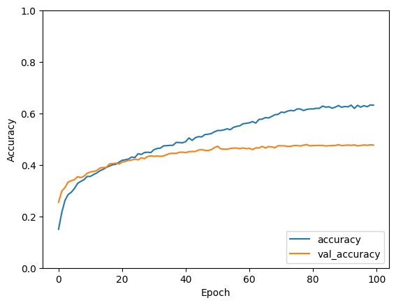

```python
# Crear un nou model sense pesos previs

model = keras.Sequential()
model.add(keras.layers.InputLayer(shape=(160, 160, 3)))
model.add(keras.layers.Resizing(32, 32))
model.add(keras.layers.Rescaling(scale=1./255.))
model.add(keras.layers.Flatten())
model.add(keras.layers.Dense(int(3072*2/3), activation='relu'))
model.add(keras.layers.Dropout(0.5))
model.add(keras.layers.Dense(int(2048/2), activation='relu'))
model.add(keras.layers.Dropout(0.5))
model.add(keras.layers.Dense(10, activation='sigmoid'))



# Compilació del model
model.compile(optimizer=keras.optimizers.Adam(learning_rate=1e-5), loss=keras.losses.CategoricalCrossentropy(),metrics=['accuracy'], )

# Definir callbacks: EarlyStopping
callback = keras.callbacks.EarlyStopping(monitor='loss', patience=10)
reduce_lr = ReduceLROnPlateau(monitor='val_loss', factor=0.2, patience=5, min_lr=1e-6)


# Entrenament del model
history = model.fit(train_dataset, epochs=100,
                    validation_data=(test_dataset),callbacks=[reduce_lr,callback])
plt.plot(history.history['accuracy'], label='accuracy')
plt.plot(history.history['val_accuracy'], label = 'val_accuracy')
plt.xlabel('Epoch')
plt.ylabel('Accuracy')
plt.ylim([0.0, 1])
plt.legend(loc='lower right')

# Validació al conjunt de prova
test_loss, test_acc = model.evaluate(val_dataset, verbose=2)
```

## 3. Petita xarxa convolucional (2 punts)

Ara implementarem una xarxa neuronal convolucional bàsica (CNN), que sol ser molt més eficaç per a la classificació de les imatges. Les CNN aprofiten l'estructura espacial de les dades mitjançant capes específiques que permeten extreure les característiques locals abans de la classificació.

**Arquitectura proposada**: Utilitzarem un model de Keras Sequential per a aquesta CNN. Consistirà en un bloc d’extractor de característiques i, a continuació, un classificador dens similar a l'anterior però més petit.

En aquesta secció utilitzarem les capes [Conv2D](https://keras.io/api/layers/convolution_layers/convolution2d/), [MaxPooling2D](https://keras.io/api/layers/pooling_layers/max_pooling2d/), [Dense](https://keras.io/api/layers/core_layers/dense/) i [Dropout](https://keras.io/api/layers/regularization_layers/dropout/) de Keras.

Es proporciona el codi del classificador ja implementat.

**Exercici 3.1 [0,5 pts]:** Analitza el codi següent i descriu les capes que formen el bloc extractor de característiques i el classificador.

```python
# Definició del model CNN
cnn_model = keras.Sequential([
    keras.layers.InputLayer(shape=(img_height, img_width, 3)),
    Rescaling(1./255),
    Conv2D(16, 3, padding='same', activation='relu'),
    MaxPooling2D(),
    Conv2D(32, 3, padding='same', activation='relu'),
    MaxPooling2D(),
    Conv2D(64, 3, padding='same', activation='relu'),
    MaxPooling2D(),
    Dropout(0.2),
    Dense(64, activation='relu'),
    Dropout(0.5),
    Dense(10, activation='softmax')
], name="CNN_model")
cnn_model.summary()
```

```
Model: "CNN_model"
```

```
┏━━━━━━━━━━━━━━━━━━━━━━━━━━━━━━━━━━━━━━┳━━━━━━━━━━━━━━━━━━━━━━━━━━━━━┳━━━━━━━━━━━━━━━━━┓
┃ Layer (type)                         ┃ Output Shape                ┃         Param # ┃
┡━━━━━━━━━━━━━━━━━━━━━━━━━━━━━━━━━━━━━━╇━━━━━━━━━━━━━━━━━━━━━━━━━━━━━╇━━━━━━━━━━━━━━━━━┩
│ rescaling_4 (Rescaling)              │ (None, 160, 160, 3)         │               0 │
├──────────────────────────────────────┼─────────────────────────────┼─────────────────┤
│ conv2d (Conv2D)                      │ (None, 160, 160, 16)        │             448 │
├──────────────────────────────────────┼─────────────────────────────┼─────────────────┤
│ max_pooling2d (MaxPooling2D)         │ (None, 80, 80, 16)          │               0 │
├──────────────────────────────────────┼─────────────────────────────┼─────────────────┤
│ conv2d_1 (Conv2D)                    │ (None, 80, 80, 32)          │           4,640 │
├──────────────────────────────────────┼─────────────────────────────┼─────────────────┤
│ max_pooling2d_1 (MaxPooling2D)       │ (None, 40, 40, 32)          │               0 │
├──────────────────────────────────────┼─────────────────────────────┼─────────────────┤
│ conv2d_2 (Conv2D)                    │ (None, 40, 40, 64)          │          18,496 │
├──────────────────────────────────────┼─────────────────────────────┼─────────────────┤
│ max_pooling2d_2 (MaxPooling2D)       │ (None, 20, 20, 64)          │               0 │
├──────────────────────────────────────┼─────────────────────────────┼─────────────────┤
│ dropout_8 (Dropout)                  │ (None, 20, 20, 64)          │               0 │
├──────────────────────────────────────┼─────────────────────────────┼─────────────────┤
│ dense_12 (Dense)                     │ (None, 20, 20, 64)          │           4,160 │
├──────────────────────────────────────┼─────────────────────────────┼─────────────────┤
│ dropout_9 (Dropout)                  │ (None, 20, 20, 64)          │               0 │
├──────────────────────────────────────┼─────────────────────────────┼─────────────────┤
│ dense_13 (Dense)                     │ (None, 20, 20, 10)          │             650 │
└──────────────────────────────────────┴─────────────────────────────┴─────────────────┘
```

```
 Total params: 28,394 (110.91 KB)
```

```
 Trainable params: 28,394 (110.91 KB)
```

```
 Non-trainable params: 0 (0.00 B)
```

**Resposta:**

- Bloc convolucional: Primer reescalem els valors perque estinguin entre 0 i 1 despres utilizem un kernel 3x3 amb 16 canals i posem padding perque es mantignui la dimensio igual, la activacio que utilizem es relu. despres utilizem maxpooling amb els parametres base que son 2x2 amb stride 2 per tant la dimensio es redueix a la meitat. despres repetim el proces d'aquestes dues caper duplicant cada vegada els canals i reduint a la eitat la dimensio per tant acabem amb una 20x20x64
- Classificador final:despres tenm dues capes totalment conectades amb dos dropouts del 0,2 y 0,5 respectivament /li>

**Exercici 3.2 [0.5 pts]**: Compila el model amb l'optimitzador **Adam** i *learning rate* = 1e-4. Entrena el model durant **100 èpoques**, utilitzant:

- *EarlyStopping* monitoritzant la pèrdua (*loss*) en validació, amb paciència de 10 èpoques, restaurant els millors pesos obtinguts.
- *ReduceLROnPlateau* monitoritzant la pèrdua (*loss*) en validació, factor 0.2, paciència de 5 èpoques i un learning rate mínim de 1e-6
- La mètrica de rendiment *accuracy* tant en entrenament com en validació.

Mostra una gràfica de les corbes d'accuracy i loss per als conjunts d'entrenament i validació. Finalment, avalua el model entrenat sobre el conjunt de test, mostrant la pèrdua i exactitud (accuracy) final obtingudes en aquestes dades. **Nota: durant l'execució del codi es produirà un error.** Explica a què és degut l'error en l'execució anterior i modifica el model per solucionar-lo. **Nota: es valorarà la concisió a les preguntes (una o dues frases són suficients per a cadascuna de les respostes).**

```python
# Compilar model CNN
cnn_model.compile(optimizer=keras.optimizers.Adam(learning_rate=1e-4), loss=keras.losses.CategoricalCrossentropy(),metrics=['accuracy'], )
```

```python
# Definir callbacks EarlyStopping y ReduceLROnPlateau
callback = keras.callbacks.EarlyStopping(monitor='loss', patience=10)
reduce_lr = ReduceLROnPlateau(monitor='val_loss', factor=0.2, patience=5, min_lr=1e-6)
```

```python
# Entrenament del model CNN
history = cnn_model.fit(train_dataset, epochs=100,
                    validation_data=(test_dataset),callbacks=[reduce_lr,callback])
plt.plot(history.history['accuracy'], label='accuracy')
plt.plot(history.history['val_accuracy'], label = 'val_accuracy')
plt.xlabel('Epoch')
plt.ylabel('Accuracy')
plt.ylim([0.0, 1])
plt.legend(loc='lower right')
```

```
---------------------------------------------------------------------------
ValueError                                Traceback (most recent call last)
<ipython-input-31-a3390623661a> in <cell line: 2>()
      1 # Entrenament del model CNN
----> 2 history = cnn_model.fit(train_dataset, epochs=100,
      3                     validation_data=(test_dataset),callbacks=[reduce_lr,callback])
      4 plt.plot(history.history['accuracy'], label='accuracy')
      5 plt.plot(history.history['val_accuracy'], label = 'val_accuracy')

/usr/local/lib/python3.10/dist-packages/keras/src/utils/traceback_utils.py in error_handler(*args, **kwargs)
    120             # To get the full stack trace, call:
    121             # `keras.config.disable_traceback_filtering()`
--> 122             raise e.with_traceback(filtered_tb) from None
    123         finally:
    124             del filtered_tb

/usr/local/lib/python3.10/dist-packages/keras/src/backend/tensorflow/nn.py in sparse_categorical_crossentropy(target, output, from_logits, axis)
    650         )
    651     if len(target.shape) != len(output.shape[:-1]):
--> 652         raise ValueError(
    653             "Argument `output` must have rank (ndim) `target.ndim - 1`. "
    654             "Received: "

ValueError: Argument `output` must have rank (ndim) `target.ndim - 1`. Received: target.shape=(None, 10), output.shape=(None, 20, 20, 10)
```

**Comentaris:**  
El problema es que no hem aplanat la capa per tant seguiem tenit matrius i per tant el output final no tenia la mateixa dimensio que el output que nosaltres probeiem via test

```python
# Escriu aquí el model corregit
cnn_model = keras.Sequential([
    keras.layers.InputLayer(shape=(img_height, img_width, 3)),
    Rescaling(1./255),
    Conv2D(16, 3, padding='same', activation='relu'),
    MaxPooling2D(),
    Conv2D(32, 3, padding='same', activation='relu'),
    MaxPooling2D(),
    Conv2D(64, 3, padding='same', activation='relu'),
    MaxPooling2D(),
    keras.layers.Flatten(),
    Dropout(0.2),
    Dense(64, activation='relu'),
    Dropout(0.5),
    Dense(10, activation='softmax')
], name="CNN_model")
cnn_model.summary()
```

```
Model: "CNN_model"
```

```
┏━━━━━━━━━━━━━━━━━━━━━━━━━━━━━━━━━━━━━━┳━━━━━━━━━━━━━━━━━━━━━━━━━━━━━┳━━━━━━━━━━━━━━━━━┓
┃ Layer (type)                         ┃ Output Shape                ┃         Param # ┃
┡━━━━━━━━━━━━━━━━━━━━━━━━━━━━━━━━━━━━━━╇━━━━━━━━━━━━━━━━━━━━━━━━━━━━━╇━━━━━━━━━━━━━━━━━┩
│ rescaling_1 (Rescaling)              │ (None, 160, 160, 3)         │               0 │
├──────────────────────────────────────┼─────────────────────────────┼─────────────────┤
│ conv2d_3 (Conv2D)                    │ (None, 160, 160, 16)        │             448 │
├──────────────────────────────────────┼─────────────────────────────┼─────────────────┤
│ max_pooling2d_3 (MaxPooling2D)       │ (None, 80, 80, 16)          │               0 │
├──────────────────────────────────────┼─────────────────────────────┼─────────────────┤
│ conv2d_4 (Conv2D)                    │ (None, 80, 80, 32)          │           4,640 │
├──────────────────────────────────────┼─────────────────────────────┼─────────────────┤
│ max_pooling2d_4 (MaxPooling2D)       │ (None, 40, 40, 32)          │               0 │
├──────────────────────────────────────┼─────────────────────────────┼─────────────────┤
│ conv2d_5 (Conv2D)                    │ (None, 40, 40, 64)          │          18,496 │
├──────────────────────────────────────┼─────────────────────────────┼─────────────────┤
│ max_pooling2d_5 (MaxPooling2D)       │ (None, 20, 20, 64)          │               0 │
├──────────────────────────────────────┼─────────────────────────────┼─────────────────┤
│ flatten_1 (Flatten)                  │ (None, 25600)               │               0 │
├──────────────────────────────────────┼─────────────────────────────┼─────────────────┤
│ dropout_2 (Dropout)                  │ (None, 25600)               │               0 │
├──────────────────────────────────────┼─────────────────────────────┼─────────────────┤
│ dense_2 (Dense)                      │ (None, 64)                  │       1,638,464 │
├──────────────────────────────────────┼─────────────────────────────┼─────────────────┤
│ dropout_3 (Dropout)                  │ (None, 64)                  │               0 │
├──────────────────────────────────────┼─────────────────────────────┼─────────────────┤
│ dense_3 (Dense)                      │ (None, 10)                  │             650 │
└──────────────────────────────────────┴─────────────────────────────┴─────────────────┘
```

```
 Total params: 1,662,698 (6.34 MB)
```

```
 Trainable params: 1,662,698 (6.34 MB)
```

```
 Non-trainable params: 0 (0.00 B)
```

**Exercici 3.3 [0.5 pt]:** Torna a repetir l'exercici anterior (entrenament, mostrar gràfiques i validació en el conjunt de test) amb el model corregit. Comenta la mida del model, el nombre d'epochs/temps d'entrenament, les corbes d'entrenament i els resultats de validació.  
**NOTA: Es valorarà la concisió en la resposta a les preguntes (una o dues frases són suficients per a cadascuna de les respostes).**

```python
# Compilar model CNN
cnn_model.compile(optimizer=keras.optimizers.Adam(learning_rate=1e-4), loss=keras.losses.CategoricalCrossentropy(),metrics=['accuracy'], )
```

```python
# Definir callbacks EarlyStopping y ReduceLROnPlateau
callback = keras.callbacks.EarlyStopping(monitor='loss', patience=10)
reduce_lr = ReduceLROnPlateau(monitor='val_loss', factor=0.2, patience=5, min_lr=1e-6)
```

```python
# Entrenament del model CNN
history = cnn_model.fit(train_dataset, epochs=100,
                    validation_data=(test_dataset),callbacks=[reduce_lr,callback])
```

```
148/148 ━━━━━━━━━━━━━━━━━━━━ 18s 83ms/step - accuracy: 0.1613 - loss: 2.2511 - val_accuracy: 0.3810 - val_loss: 1.9743 - learning_rate: 1.0000e-04
148/148 ━━━━━━━━━━━━━━━━━━━━ 7s 46ms/step - accuracy: 0.3095 - loss: 1.9888 - val_accuracy: 0.4030 - val_loss: 1.8447 - learning_rate: 1.0000e-04
148/148 ━━━━━━━━━━━━━━━━━━━━ 7s 48ms/step - accuracy: 0.3664 - loss: 1.8484 - val_accuracy: 0.4666 - val_loss: 1.7009 - learning_rate: 1.0000e-04
148/148 ━━━━━━━━━━━━━━━━━━━━ 7s 46ms/step - accuracy: 0.4075 - loss: 1.7565 - val_accuracy: 0.4997 - val_loss: 1.6054 - learning_rate: 1.0000e-04
148/148 ━━━━━━━━━━━━━━━━━━━━ 7s 46ms/step - accuracy: 0.4391 - loss: 1.6758 - val_accuracy: 0.5374 - val_loss: 1.5294 - learning_rate: 1.0000e-04
148/148 ━━━━━━━━━━━━━━━━━━━━ 7s 44ms/step - accuracy: 0.4671 - loss: 1.6022 - val_accuracy: 0.5410 - val_loss: 1.4614 - learning_rate: 1.0000e-04
148/148 ━━━━━━━━━━━━━━━━━━━━ 7s 44ms/step - accuracy: 0.4757 - loss: 1.5593 - val_accuracy: 0.5685 - val_loss: 1.4078 - learning_rate: 1.0000e-04
148/148 ━━━━━━━━━━━━━━━━━━━━ 7s 47ms/step - accuracy: 0.5062 - loss: 1.4852 - val_accuracy: 0.5685 - val_loss: 1.3800 - learning_rate: 1.0000e-04
148/148 ━━━━━━━━━━━━━━━━━━━━ 7s 44ms/step - accuracy: 0.5228 - loss: 1.4484 - val_accuracy: 0.5823 - val_loss: 1.3382 - learning_rate: 1.0000e-04
148/148 ━━━━━━━━━━━━━━━━━━━━ 7s 48ms/step - accuracy: 0.5355 - loss: 1.3932 - val_accuracy: 0.5960 - val_loss: 1.2759 - learning_rate: 1.0000e-04
148/148 ━━━━━━━━━━━━━━━━━━━━ 7s 45ms/step - accuracy: 0.5473 - loss: 1.3747 - val_accuracy: 0.5940 - val_loss: 1.2629 - learning_rate: 1.0000e-04
148/148 ━━━━━━━━━━━━━━━━━━━━ 7s 47ms/step - accuracy: 0.5555 - loss: 1.3297 - val_accuracy: 0.6037 - val_loss: 1.2480 - learning_rate: 1.0000e-04
148/148 ━━━━━━━━━━━━━━━━━━━━ 7s 47ms/step - accuracy: 0.5689 - loss: 1.3108 - val_accuracy: 0.6103 - val_loss: 1.2261 - learning_rate: 1.0000e-04
148/148 ━━━━━━━━━━━━━━━━━━━━ 7s 48ms/step - accuracy: 0.5794 - loss: 1.2619 - val_accuracy: 0.6230 - val_loss: 1.2005 - learning_rate: 1.0000e-04
148/148 ━━━━━━━━━━━━━━━━━━━━ 7s 45ms/step - accuracy: 0.5976 - loss: 1.2098 - val_accuracy: 0.6281 - val_loss: 1.2012 - learning_rate: 1.0000e-04
148/148 ━━━━━━━━━━━━━━━━━━━━ 7s 46ms/step - accuracy: 0.6057 - loss: 1.1934 - val_accuracy: 0.6276 - val_loss: 1.1789 - learning_rate: 1.0000e-04
148/148 ━━━━━━━━━━━━━━━━━━━━ 7s 48ms/step - accuracy: 0.6045 - loss: 1.1874 - val_accuracy: 0.6220 - val_loss: 1.1733 - learning_rate: 1.0000e-04
148/148 ━━━━━━━━━━━━━━━━━━━━ 7s 47ms/step - accuracy: 0.6213 - loss: 1.1421 - val_accuracy: 0.6251 - val_loss: 1.1594 - learning_rate: 1.0000e-04
148/148 ━━━━━━━━━━━━━━━━━━━━ 7s 46ms/step - accuracy: 0.6215 - loss: 1.1114 - val_accuracy: 0.6388 - val_loss: 1.1465 - learning_rate: 1.0000e-04
148/148 ━━━━━━━━━━━━━━━━━━━━ 7s 46ms/step - accuracy: 0.6458 - loss: 1.0821 - val_accuracy: 0.6373 - val_loss: 1.1297 - learning_rate: 1.0000e-04
148/148 ━━━━━━━━━━━━━━━━━━━━ 7s 48ms/step - accuracy: 0.6406 - loss: 1.0722 - val_accuracy: 0.6307 - val_loss: 1.1335 - learning_rate: 1.0000e-04
148/148 ━━━━━━━━━━━━━━━━━━━━ 7s 50ms/step - accuracy: 0.6512 - loss: 1.0530 - val_accuracy: 0.6398 - val_loss: 1.1069 - learning_rate: 1.0000e-04
148/148 ━━━━━━━━━━━━━━━━━━━━ 7s 44ms/step - accuracy: 0.6594 - loss: 1.0046 - val_accuracy: 0.6429 - val_loss: 1.1153 - learning_rate: 1.0000e-04
148/148 ━━━━━━━━━━━━━━━━━━━━ 7s 44ms/step - accuracy: 0.6831 - loss: 0.9792 - val_accuracy: 0.6449 - val_loss: 1.0960 - learning_rate: 1.0000e-04
148/148 ━━━━━━━━━━━━━━━━━━━━ 7s 48ms/step - accuracy: 0.6655 - loss: 0.9790 - val_accuracy: 0.6546 - val_loss: 1.0882 - learning_rate: 1.0000e-04
148/148 ━━━━━━━━━━━━━━━━━━━━ 7s 47ms/step - accuracy: 0.6814 - loss: 0.9472 - val_accuracy: 0.6460 - val_loss: 1.0958 - learning_rate: 1.0000e-04
148/148 ━━━━━━━━━━━━━━━━━━━━ 7s 47ms/step - accuracy: 0.6807 - loss: 0.9435 - val_accuracy: 0.6521 - val_loss: 1.0915 - learning_rate: 1.0000e-04
148/148 ━━━━━━━━━━━━━━━━━━━━ 7s 48ms/step - accuracy: 0.6903 - loss: 0.9213 - val_accuracy: 0.6551 - val_loss: 1.0778 - learning_rate: 1.0000e-04
148/148 ━━━━━━━━━━━━━━━━━━━━ 7s 46ms/step - accuracy: 0.7008 - loss: 0.8965 - val_accuracy: 0.6429 - val_loss: 1.1093 - learning_rate: 1.0000e-04
148/148 ━━━━━━━━━━━━━━━━━━━━ 7s 49ms/step - accuracy: 0.6971 - loss: 0.8787 - val_accuracy: 0.6505 - val_loss: 1.1088 - learning_rate: 1.0000e-04
148/148 ━━━━━━━━━━━━━━━━━━━━ 7s 48ms/step - accuracy: 0.7118 - loss: 0.8499 - val_accuracy: 0.6526 - val_loss: 1.0862 - learning_rate: 1.0000e-04
148/148 ━━━━━━━━━━━━━━━━━━━━ 7s 44ms/step - accuracy: 0.7271 - loss: 0.8255 - val_accuracy: 0.6551 - val_loss: 1.0898 - learning_rate: 1.0000e-04
148/148 ━━━━━━━━━━━━━━━━━━━━ 7s 46ms/step - accuracy: 0.7250 - loss: 0.8088 - val_accuracy: 0.6592 - val_loss: 1.0883 - learning_rate: 1.0000e-04
148/148 ━━━━━━━━━━━━━━━━━━━━ 7s 46ms/step - accuracy: 0.7285 - loss: 0.7815 - val_accuracy: 0.6582 - val_loss: 1.0790 - learning_rate: 2.0000e-05
148/148 ━━━━━━━━━━━━━━━━━━━━ 7s 45ms/step - accuracy: 0.7492 - loss: 0.7483 - val_accuracy: 0.6617 - val_loss: 1.0788 - learning_rate: 2.0000e-05
148/148 ━━━━━━━━━━━━━━━━━━━━ 8s 52ms/step - accuracy: 0.7487 - loss: 0.7461 - val_accuracy: 0.6551 - val_loss: 1.0825 - learning_rate: 2.0000e-05
148/148 ━━━━━━━━━━━━━━━━━━━━ 7s 45ms/step - accuracy: 0.7418 - loss: 0.7572 - val_accuracy: 0.6597 - val_loss: 1.0813 - learning_rate: 2.0000e-05
148/148 ━━━━━━━━━━━━━━━━━━━━ 7s 47ms/step - accuracy: 0.7490 - loss: 0.7453 - val_accuracy: 0.6597 - val_loss: 1.0858 - learning_rate: 2.0000e-05
148/148 ━━━━━━━━━━━━━━━━━━━━ 7s 47ms/step - accuracy: 0.7572 - loss: 0.7159 - val_accuracy: 0.6643 - val_loss: 1.0788 - learning_rate: 4.0000e-06
148/148 ━━━━━━━━━━━━━━━━━━━━ 7s 47ms/step - accuracy: 0.7565 - loss: 0.7216 - val_accuracy: 0.6607 - val_loss: 1.0764 - learning_rate: 4.0000e-06
148/148 ━━━━━━━━━━━━━━━━━━━━ 7s 45ms/step - accuracy: 0.7526 - loss: 0.7317 - val_accuracy: 0.6628 - val_loss: 1.0767 - learning_rate: 4.0000e-06
```

[output cut: 21 more lines]

```
31/31 - 2s - 63ms/step - accuracy: 0.6702 - loss: 1.0579
```

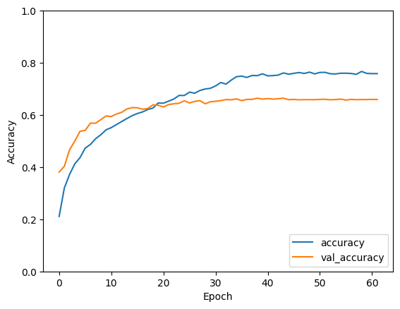

```python
# Resultats
plt.plot(history.history['accuracy'], label='accuracy')
plt.plot(history.history['val_accuracy'], label = 'val_accuracy')
plt.xlabel('Epoch')
plt.ylabel('Accuracy')
plt.ylim([0.0, 1])
plt.legend(loc='lower right')
# Validació al conjunt de prova
test_loss, test_acc = cnn_model.evaluate(val_dataset, verbose=2)
```

**Comentaris:**  
Veiem que amb els early stops que l'hem posar a convergit en 62 epoch pero la corva de test s'ha aplanat molt abans, això sembla indicar que apartir d'un punt sobre la epoch 40 ha deixat de poder generalitzar i nomes aprenia per el conjunt de test, però la accuracy es molt mes alta que abans arriban al casi 70 % i en menys epoch que abans

**Exercici 3.4 [0.5 pt]:** Realitza una comparativa entre els models dels exercicis 2 (amb el *learning rate* escollit) i 3 en termes de:

- **Mida del model**
- **Evolució de l'entrenament**
- **Validació en el conjunt de prova**
- **Temps d'execució**

**Nota: es valorarà la concisió a les preguntes (una o dues frases són suficients per a cadascuna de les respostes).**

**Comentaris:**

## 4. Augmentació de dades (1 punt)

Tot i que la CNN entrenada és força efectiva, podem intentar millorar-ne la generalització augmentant artificialment la mida i la diversitat del conjunt d'entrenament mitjançant **tècniques d'augmentació de dades**. L'augmentació consisteix a aplicar transformacions aleatòries a les imatges (girs, rotacions, zoom, etc.) de manera que el model rebi variants de les imatges originals a cada època, simulant tenir més dades

Keras proporciona capes de preprocessament d'imatge que realitzen aquestes transformacions de manera eficient durant l'entrenament, per exemple RandomFlip, RandomRotation, RandomZoom entre d'altres.

Aquí farem servir algunes d'aquestes capes per implementar l'augment. En particular, provarem de voltejar horitzontalment les imatges i aplicar petites rotacions aleatòries.

### 4.1. Definició i visualització de l'augmentació

**Exercici 4.1 [0,5 pts]:** Crea un model **Sequential** de Keras que representi una capa d'augmentació de dades amb les següents capes:

- `RandomFlip` que voltegi aleatòriament les imatges horitzontalment.
- `RandomRotation` amb factor de rotació de 0.1 (±10%).

Selecciona una imatge del conjunt d'entrenament i passa-la a través d'aquest model diverses vegades, mostrant les imatges resultants per comprovar visualment les transformacions realitzades (voltejos i rotacions).

```python
# Model d'augmentació de dades
agg_data = keras.Sequential([
    keras.layers.RandomFlip(),
    keras.layers.RandomRotation(factor=(-0.1, 0.1))

], name="agg_data")
agg_data.summary()
```

```
Model: "agg_data"
```

```
┏━━━━━━━━━━━━━━━━━━━━━━━━━━━━━━━━━━━━━━┳━━━━━━━━━━━━━━━━━━━━━━━━━━━━━┳━━━━━━━━━━━━━━━━━┓
┃ Layer (type)                         ┃ Output Shape                ┃         Param # ┃
┡━━━━━━━━━━━━━━━━━━━━━━━━━━━━━━━━━━━━━━╇━━━━━━━━━━━━━━━━━━━━━━━━━━━━━╇━━━━━━━━━━━━━━━━━┩
│ random_flip (RandomFlip)             │ ?                           │     0 (unbuilt) │
├──────────────────────────────────────┼─────────────────────────────┼─────────────────┤
│ random_rotation (RandomRotation)     │ ?                           │     0 (unbuilt) │
└──────────────────────────────────────┴─────────────────────────────┴─────────────────┘
```

```
 Total params: 0 (0.00 B)
```

```
 Trainable params: 0 (0.00 B)
```

```
 Non-trainable params: 0 (0.00 B)
```

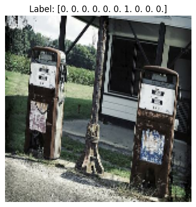

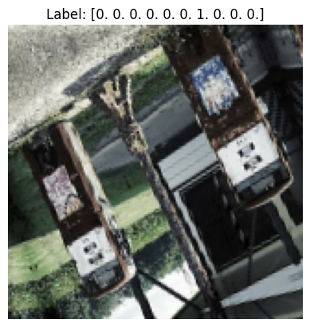

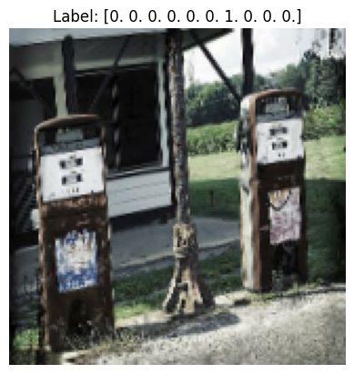

[figure not shown]

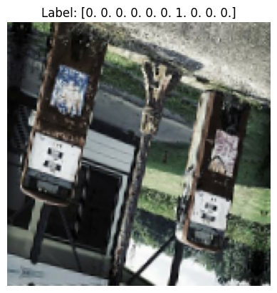

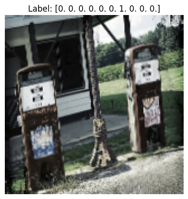

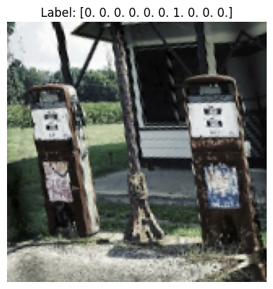

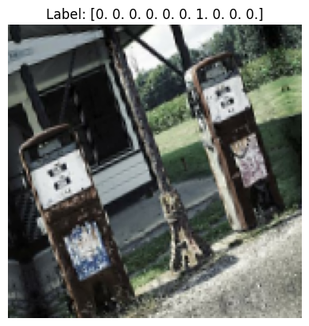

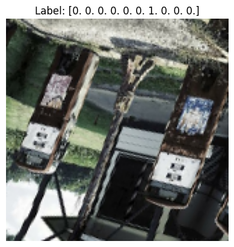

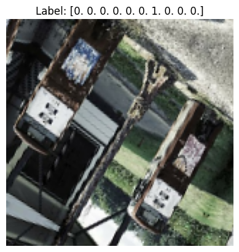

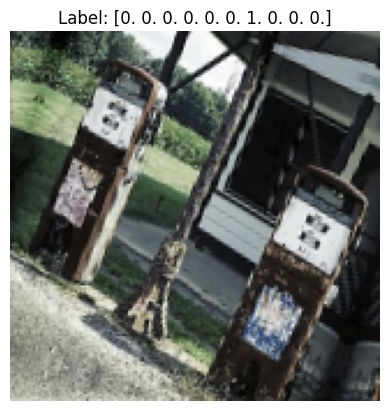

```python
# Prendre un batch d'entrenament i obtenir una imatge
for images, labels in train_dataset.unbatch().take(64):
    image = images.numpy().astype(np.int32)

    plt.imshow(image)
    plt.title(f"Label: {labels}")
    plt.axis('off')
    plt.show()
    i = 0
    # Aplicar augmentació diverses vegades i visualitzar
    while i < 10:
        rotate_data = agg_data(image).numpy().astype(np.int32)
        plt.imshow(rotate_data)
        plt.title(f"Label: {labels}")
        plt.axis('off')
        plt.show()
        i+=1
    break
```

### 4.2. Entrenament de la CNN amb augmentació

Ara incorporarem la capa d’augmentació al model CNN per entrenar-la amb dades augmentades a cada època.

**Exercici 4.2 [0,5 pts]:** Insereix el model d'augmentació de dades creat entre la capa de `Rescaling` i la primera `Conv2D` del model CNN anterior. És a dir, modifica l'arquitectura perquè les imatges d'entrada, després de ser reescalades, passin per les capes de *flip* i *rotation* aleatòries, i després continuïn per la CNN. A continuació, compila i entrena el nou model CNN augmentat seguint les mateixes indicacions que en l'exercici anterior, **excepte** que aquesta vegada farem servir un **learning rate** inicial més gran (1e-3). Mantingues EarlyStopping, ReduceLROnPlateau, 100 èpoques, etc. Després avalua el model final al conjunt de test. Comenta les diferències amb el model sense augmentació en termes de:

- **Evolució de les corbes d'entrenament**
- **Validació en el conjunt de prova**
- **Temps d'entrenament**
- **Learning rate**

**Nota: es valorarà la concisió a les preguntes (una o dues frases són suficients per a cadascuna de les respostes).**

```python
# Model CNN amb augmentació de dades
cnn_model = keras.Sequential([
    keras.layers.InputLayer(shape=(img_height, img_width, 3)),
    Rescaling(1./255),
    keras.layers.RandomFlip(),
    keras.layers.RandomRotation(factor=(-0.1, 0.1)),
    Conv2D(16, 3, padding='same', activation='relu'),
    MaxPooling2D(),
    Conv2D(32, 3, padding='same', activation='relu'),
    MaxPooling2D(),
    Conv2D(64, 3, padding='same', activation='relu'),
    MaxPooling2D(),
    keras.layers.Flatten(),
    Dropout(0.2),
    Dense(64, activation='relu'),
    Dropout(0.5),
    Dense(10, activation='softmax')
], name="CNN_model")
cnn_model.summary()
```

```
Model: "CNN_model"
```

```
┏━━━━━━━━━━━━━━━━━━━━━━━━━━━━━━━━━━━━━━┳━━━━━━━━━━━━━━━━━━━━━━━━━━━━━┳━━━━━━━━━━━━━━━━━┓
┃ Layer (type)                         ┃ Output Shape                ┃         Param # ┃
┡━━━━━━━━━━━━━━━━━━━━━━━━━━━━━━━━━━━━━━╇━━━━━━━━━━━━━━━━━━━━━━━━━━━━━╇━━━━━━━━━━━━━━━━━┩
│ rescaling (Rescaling)                │ (None, 160, 160, 3)         │               0 │
├──────────────────────────────────────┼─────────────────────────────┼─────────────────┤
│ random_flip_1 (RandomFlip)           │ (None, 160, 160, 3)         │               0 │
├──────────────────────────────────────┼─────────────────────────────┼─────────────────┤
│ random_rotation_1 (RandomRotation)   │ (None, 160, 160, 3)         │               0 │
├──────────────────────────────────────┼─────────────────────────────┼─────────────────┤
│ conv2d (Conv2D)                      │ (None, 160, 160, 16)        │             448 │
├──────────────────────────────────────┼─────────────────────────────┼─────────────────┤
│ max_pooling2d (MaxPooling2D)         │ (None, 80, 80, 16)          │               0 │
├──────────────────────────────────────┼─────────────────────────────┼─────────────────┤
│ conv2d_1 (Conv2D)                    │ (None, 80, 80, 32)          │           4,640 │
├──────────────────────────────────────┼─────────────────────────────┼─────────────────┤
│ max_pooling2d_1 (MaxPooling2D)       │ (None, 40, 40, 32)          │               0 │
├──────────────────────────────────────┼─────────────────────────────┼─────────────────┤
│ conv2d_2 (Conv2D)                    │ (None, 40, 40, 64)          │          18,496 │
├──────────────────────────────────────┼─────────────────────────────┼─────────────────┤
│ max_pooling2d_2 (MaxPooling2D)       │ (None, 20, 20, 64)          │               0 │
├──────────────────────────────────────┼─────────────────────────────┼─────────────────┤
│ flatten (Flatten)                    │ (None, 25600)               │               0 │
├──────────────────────────────────────┼─────────────────────────────┼─────────────────┤
│ dropout (Dropout)                    │ (None, 25600)               │               0 │
├──────────────────────────────────────┼─────────────────────────────┼─────────────────┤
│ dense (Dense)                        │ (None, 64)                  │       1,638,464 │
├──────────────────────────────────────┼─────────────────────────────┼─────────────────┤
│ dropout_1 (Dropout)                  │ (None, 64)                  │               0 │
├──────────────────────────────────────┼─────────────────────────────┼─────────────────┤
│ dense_1 (Dense)                      │ (None, 10)                  │             650 │
└──────────────────────────────────────┴─────────────────────────────┴─────────────────┘
```

```
 Total params: 1,662,698 (6.34 MB)
```

```
 Trainable params: 1,662,698 (6.34 MB)
```

```
 Non-trainable params: 0 (0.00 B)
```

```python
# Compilació de la xarxa
cnn_model.compile(optimizer=keras.optimizers.Adam(learning_rate=1e-3), loss=keras.losses.CategoricalCrossentropy(),metrics=['accuracy'], )
```

```python
# Definir callbacks EarlyStopping y ReduceLROnPlateau
callback = keras.callbacks.EarlyStopping(monitor='loss', patience=10,verbose=1)
reduce_lr = ReduceLROnPlateau(monitor='val_loss', factor=0.2, patience=5, min_lr=1e-6)
```

```python
# Entrenament
history = cnn_model.fit(train_dataset, epochs=100,
                    validation_data=(test_dataset),callbacks=[reduce_lr,callback])
```

```
148/148 ━━━━━━━━━━━━━━━━━━━━ 27s 153ms/step - accuracy: 0.1250 - loss: 2.3389 - val_accuracy: 0.2084 - val_loss: 2.1238 - learning_rate: 0.0010
148/148 ━━━━━━━━━━━━━━━━━━━━ 7s 47ms/step - accuracy: 0.2087 - loss: 2.1312 - val_accuracy: 0.3291 - val_loss: 1.8943 - learning_rate: 0.0010
148/148 ━━━━━━━━━━━━━━━━━━━━ 7s 46ms/step - accuracy: 0.2841 - loss: 1.9547 - val_accuracy: 0.4361 - val_loss: 1.7150 - learning_rate: 0.0010
148/148 ━━━━━━━━━━━━━━━━━━━━ 7s 45ms/step - accuracy: 0.3283 - loss: 1.8648 - val_accuracy: 0.4452 - val_loss: 1.6922 - learning_rate: 0.0010
148/148 ━━━━━━━━━━━━━━━━━━━━ 7s 45ms/step - accuracy: 0.3671 - loss: 1.7980 - val_accuracy: 0.4967 - val_loss: 1.5597 - learning_rate: 0.0010
148/148 ━━━━━━━━━━━━━━━━━━━━ 7s 48ms/step - accuracy: 0.3942 - loss: 1.7170 - val_accuracy: 0.4697 - val_loss: 1.5766 - learning_rate: 0.0010
148/148 ━━━━━━━━━━━━━━━━━━━━ 7s 50ms/step - accuracy: 0.4034 - loss: 1.6966 - val_accuracy: 0.5130 - val_loss: 1.4959 - learning_rate: 0.0010
148/148 ━━━━━━━━━━━━━━━━━━━━ 7s 48ms/step - accuracy: 0.4199 - loss: 1.6682 - val_accuracy: 0.5303 - val_loss: 1.4764 - learning_rate: 0.0010
148/148 ━━━━━━━━━━━━━━━━━━━━ 7s 46ms/step - accuracy: 0.4380 - loss: 1.6118 - val_accuracy: 0.5242 - val_loss: 1.4918 - learning_rate: 0.0010
148/148 ━━━━━━━━━━━━━━━━━━━━ 7s 48ms/step - accuracy: 0.4558 - loss: 1.5819 - val_accuracy: 0.5329 - val_loss: 1.4054 - learning_rate: 0.0010
148/148 ━━━━━━━━━━━━━━━━━━━━ 7s 48ms/step - accuracy: 0.4693 - loss: 1.5400 - val_accuracy: 0.5685 - val_loss: 1.3711 - learning_rate: 0.0010
148/148 ━━━━━━━━━━━━━━━━━━━━ 7s 48ms/step - accuracy: 0.4769 - loss: 1.5098 - val_accuracy: 0.5818 - val_loss: 1.3423 - learning_rate: 0.0010
148/148 ━━━━━━━━━━━━━━━━━━━━ 7s 47ms/step - accuracy: 0.4875 - loss: 1.4849 - val_accuracy: 0.5767 - val_loss: 1.3093 - learning_rate: 0.0010
148/148 ━━━━━━━━━━━━━━━━━━━━ 8s 51ms/step - accuracy: 0.4981 - loss: 1.4690 - val_accuracy: 0.5965 - val_loss: 1.2995 - learning_rate: 0.0010
148/148 ━━━━━━━━━━━━━━━━━━━━ 8s 51ms/step - accuracy: 0.5108 - loss: 1.4526 - val_accuracy: 0.5751 - val_loss: 1.3169 - learning_rate: 0.0010
148/148 ━━━━━━━━━━━━━━━━━━━━ 8s 54ms/step - accuracy: 0.5025 - loss: 1.4611 - val_accuracy: 0.5537 - val_loss: 1.4180 - learning_rate: 0.0010
148/148 ━━━━━━━━━━━━━━━━━━━━ 7s 50ms/step - accuracy: 0.5083 - loss: 1.4298 - val_accuracy: 0.5838 - val_loss: 1.2872 - learning_rate: 0.0010
148/148 ━━━━━━━━━━━━━━━━━━━━ 7s 49ms/step - accuracy: 0.5143 - loss: 1.4240 - val_accuracy: 0.6240 - val_loss: 1.1865 - learning_rate: 0.0010
148/148 ━━━━━━━━━━━━━━━━━━━━ 8s 51ms/step - accuracy: 0.5248 - loss: 1.3841 - val_accuracy: 0.6195 - val_loss: 1.2005 - learning_rate: 0.0010
148/148 ━━━━━━━━━━━━━━━━━━━━ 8s 53ms/step - accuracy: 0.5274 - loss: 1.3987 - val_accuracy: 0.6454 - val_loss: 1.1548 - learning_rate: 0.0010
148/148 ━━━━━━━━━━━━━━━━━━━━ 7s 49ms/step - accuracy: 0.5333 - loss: 1.3679 - val_accuracy: 0.6327 - val_loss: 1.1660 - learning_rate: 0.0010
148/148 ━━━━━━━━━━━━━━━━━━━━ 8s 51ms/step - accuracy: 0.5466 - loss: 1.3454 - val_accuracy: 0.6190 - val_loss: 1.2261 - learning_rate: 0.0010
148/148 ━━━━━━━━━━━━━━━━━━━━ 8s 52ms/step - accuracy: 0.5450 - loss: 1.3346 - val_accuracy: 0.6271 - val_loss: 1.1495 - learning_rate: 0.0010
148/148 ━━━━━━━━━━━━━━━━━━━━ 8s 55ms/step - accuracy: 0.5364 - loss: 1.3499 - val_accuracy: 0.6419 - val_loss: 1.1720 - learning_rate: 0.0010
148/148 ━━━━━━━━━━━━━━━━━━━━ 7s 49ms/step - accuracy: 0.5463 - loss: 1.3289 - val_accuracy: 0.6373 - val_loss: 1.1628 - learning_rate: 0.0010
148/148 ━━━━━━━━━━━━━━━━━━━━ 7s 49ms/step - accuracy: 0.5524 - loss: 1.3287 - val_accuracy: 0.6276 - val_loss: 1.1683 - learning_rate: 0.0010
148/148 ━━━━━━━━━━━━━━━━━━━━ 7s 50ms/step - accuracy: 0.5609 - loss: 1.2784 - val_accuracy: 0.6414 - val_loss: 1.1472 - learning_rate: 0.0010
148/148 ━━━━━━━━━━━━━━━━━━━━ 7s 48ms/step - accuracy: 0.5484 - loss: 1.3291 - val_accuracy: 0.6582 - val_loss: 1.0879 - learning_rate: 0.0010
148/148 ━━━━━━━━━━━━━━━━━━━━ 8s 51ms/step - accuracy: 0.5726 - loss: 1.2679 - val_accuracy: 0.6098 - val_loss: 1.1975 - learning_rate: 0.0010
148/148 ━━━━━━━━━━━━━━━━━━━━ 7s 50ms/step - accuracy: 0.5632 - loss: 1.2750 - val_accuracy: 0.6612 - val_loss: 1.0793 - learning_rate: 0.0010
148/148 ━━━━━━━━━━━━━━━━━━━━ 7s 46ms/step - accuracy: 0.5565 - loss: 1.2890 - val_accuracy: 0.6510 - val_loss: 1.1163 - learning_rate: 0.0010
148/148 ━━━━━━━━━━━━━━━━━━━━ 7s 50ms/step - accuracy: 0.5819 - loss: 1.2576 - val_accuracy: 0.6414 - val_loss: 1.1105 - learning_rate: 0.0010
148/148 ━━━━━━━━━━━━━━━━━━━━ 8s 51ms/step - accuracy: 0.5773 - loss: 1.2384 - val_accuracy: 0.6398 - val_loss: 1.1355 - learning_rate: 0.0010
148/148 ━━━━━━━━━━━━━━━━━━━━ 7s 48ms/step - accuracy: 0.5695 - loss: 1.2558 - val_accuracy: 0.6602 - val_loss: 1.0743 - learning_rate: 0.0010
148/148 ━━━━━━━━━━━━━━━━━━━━ 7s 47ms/step - accuracy: 0.5717 - loss: 1.2546 - val_accuracy: 0.6607 - val_loss: 1.0695 - learning_rate: 0.0010
148/148 ━━━━━━━━━━━━━━━━━━━━ 7s 47ms/step - accuracy: 0.5707 - loss: 1.2501 - val_accuracy: 0.6811 - val_loss: 1.0069 - learning_rate: 0.0010
148/148 ━━━━━━━━━━━━━━━━━━━━ 8s 52ms/step - accuracy: 0.5799 - loss: 1.2335 - val_accuracy: 0.6679 - val_loss: 1.0545 - learning_rate: 0.0010
148/148 ━━━━━━━━━━━━━━━━━━━━ 7s 47ms/step - accuracy: 0.5904 - loss: 1.2126 - val_accuracy: 0.6663 - val_loss: 1.0718 - learning_rate: 0.0010
148/148 ━━━━━━━━━━━━━━━━━━━━ 7s 46ms/step - accuracy: 0.5826 - loss: 1.2192 - val_accuracy: 0.6531 - val_loss: 1.1107 - learning_rate: 0.0010
148/148 ━━━━━━━━━━━━━━━━━━━━ 7s 44ms/step - accuracy: 0.5888 - loss: 1.2125 - val_accuracy: 0.6475 - val_loss: 1.1424 - learning_rate: 0.0010
```

[output cut: 11 more lines]

```
148/148 ━━━━━━━━━━━━━━━━━━━━ 7s 46ms/step - accuracy: 0.6271 - loss: 1.0850 - val_accuracy: 0.6908 - val_loss: 0.9906 - learning_rate: 4.0000e-05
148/148 ━━━━━━━━━━━━━━━━━━━━ 7s 47ms/step - accuracy: 0.6281 - loss: 1.0811 - val_accuracy: 0.6938 - val_loss: 0.9908 - learning_rate: 4.0000e-05
148/148 ━━━━━━━━━━━━━━━━━━━━ 7s 45ms/step - accuracy: 0.6369 - loss: 1.0924 - val_accuracy: 0.6872 - val_loss: 0.9969 - learning_rate: 4.0000e-05
148/148 ━━━━━━━━━━━━━━━━━━━━ 7s 47ms/step - accuracy: 0.6382 - loss: 1.0695 - val_accuracy: 0.6877 - val_loss: 0.9905 - learning_rate: 8.0000e-06
148/148 ━━━━━━━━━━━━━━━━━━━━ 7s 50ms/step - accuracy: 0.6300 - loss: 1.0726 - val_accuracy: 0.6862 - val_loss: 0.9920 - learning_rate: 8.0000e-06
148/148 ━━━━━━━━━━━━━━━━━━━━ 7s 45ms/step - accuracy: 0.6263 - loss: 1.0836 - val_accuracy: 0.6862 - val_loss: 0.9941 - learning_rate: 8.0000e-06
148/148 ━━━━━━━━━━━━━━━━━━━━ 7s 45ms/step - accuracy: 0.6362 - loss: 1.0878 - val_accuracy: 0.6852 - val_loss: 0.9907 - learning_rate: 8.0000e-06
148/148 ━━━━━━━━━━━━━━━━━━━━ 7s 45ms/step - accuracy: 0.6314 - loss: 1.0842 - val_accuracy: 0.6862 - val_loss: 0.9925 - learning_rate: 8.0000e-06
148/148 ━━━━━━━━━━━━━━━━━━━━ 7s 47ms/step - accuracy: 0.6277 - loss: 1.0831 - val_accuracy: 0.6872 - val_loss: 0.9920 - learning_rate: 1.6000e-06
148/148 ━━━━━━━━━━━━━━━━━━━━ 7s 50ms/step - accuracy: 0.6247 - loss: 1.0792 - val_accuracy: 0.6867 - val_loss: 0.9922 - learning_rate: 1.6000e-06
148/148 ━━━━━━━━━━━━━━━━━━━━ 7s 45ms/step - accuracy: 0.6351 - loss: 1.0860 - val_accuracy: 0.6867 - val_loss: 0.9909 - learning_rate: 1.6000e-06
148/148 ━━━━━━━━━━━━━━━━━━━━ 7s 45ms/step - accuracy: 0.6268 - loss: 1.0968 - val_accuracy: 0.6862 - val_loss: 0.9913 - learning_rate: 1.6000e-06
148/148 ━━━━━━━━━━━━━━━━━━━━ 7s 46ms/step - accuracy: 0.6326 - loss: 1.0821 - val_accuracy: 0.6867 - val_loss: 0.9914 - learning_rate: 1.6000e-06
148/148 ━━━━━━━━━━━━━━━━━━━━ 8s 53ms/step - accuracy: 0.6300 - loss: 1.0815 - val_accuracy: 0.6867 - val_loss: 0.9915 - learning_rate: 1.0000e-06
Epoch 65: early stopping
```

```
31/31 - 5s - 150ms/step - accuracy: 0.6896 - loss: 0.9987
```

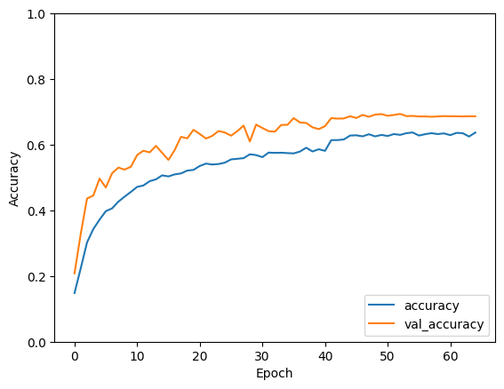

```python
# Resultats

plt.plot(history.history['accuracy'], label='accuracy')
plt.plot(history.history['val_accuracy'], label = 'val_accuracy')
plt.xlabel('Epoch')
plt.ylabel('Accuracy')
plt.ylim([0.0, 1])
plt.legend(loc='lower right')
# Validació al conjunt de prova
test_loss, test_acc = cnn_model.evaluate(val_dataset, verbose=2)
```

**Comentaris:**

- **Evolució de les corbes d'entrenament**: Veiem que inclus amb una learnig rate més alta hem tardat mes en convergir en test, i la linea no s'ha aplanat tant per tant seguiem aprenent inclus en epoch més altes per tant generalitzabem millor
- **Validació en el conjunt de prova**: Veiem que tenim una acuracy una mica millor i veiem una cosa una mica extranya que la accuracy es més bona a test que a train quan sol ser al reves, això deu ser perque els valors a test no estan rotats
- **Temps d'entrenament**: Tenit en compte la epoch on ha fet early stoping veiem que es molt similar
- **Learning rate**: l'hem posat un learnig rate més agresiu i no lo ha donat problemes de arribar a minims locals i hem convergit millor, crec que es lo adecuat perque tenim més variabilitat a les imatges per tant es menys probable que ens quedem a un minim local i podem ser mes agresius a l'hora de baixar per la pendent

## 5. Superresolució d’imatges amb CNNs (2 pts)

Fins ara hem treballat en un problema de “classificació”. Als apartats restants abordarem un problema diferent però relacionat amb la visió per computador: la **superresolució d'imatges**. La superresolució consisteix a generar una imatge d'alta resolució (HR) a partir d'una de baixa resolució (LR), intentant recuperar o inferir els detalls perduts en reduir la imatge. És un problema d'aprenentatge supervisat on el model aprèn una transformació imatge->imatge.

Farem servir novament la base de dades Imagenette per crear exemples d'entrenament: a partir de cada imatge original (320px) generarem una versió reduïda (p. ex. 80px) que servirà com a entrada, tenint com a sortida esperada la imatge original. Així, el model aprendrà a mapejar de baixa a alta resolució. En lloc d'una xarxa convolucional per a la classificació, necessitarem una xarxa capaç de processar una imatge d'entrada i produir una imatge de sortida. Les **capes transposades de convolució** ([Conv2DTranspose](https://keras.io/api/layers/convolution_layers/convolution2d_transpose/)) o les tècniques de upsampling són les peces clau per a aquests models, ja que permeten augmentar les dimensions espacials de les dades.

A continuació, crearem el conjunt de dades per a superresolució i entrenarem una **CNN de superresolució simple**.

### 5.1. Preparació de dades de LR/HR

Primer generarem els parells d'imatges d'entrenament i de validació per a superresolució. Partirem de les imatges originals d'entrenament (i validació) a la seva resolució completa i, per simplicitat, les redimensionarem a una mida fixa de 320×320 (ignorant la relació d'aspecte original, similar al fet en classificació) per utilitzar-les com a imatges de referència d'alta resolució (HR), i les reduirem a 1/4 de la seva mida (aprox). Per realitzar ambdues transformacions (ajust de les imatges originals a 320x320 i la seva reducció a 80x80) utilitzarem mètodes d'[interpolació bicúbica](https://es.wikipedia.org/wiki/Interpolaci%C3%B3n_bic%C3%BAbica) per simular imatges degrades suaument.

Procedim a obtenir les rutes d'imatges d'entrenament i validació, després creem un Dataset aplicant la funció de mapeig que realitza la lectura i la transformació:

**Exercici 5.1.1 [0,5 pt]:** El codi següent prepara un nou conjunt de dades a partir de les imatges d'entrenament originals. Cada exemple consistirà en una imatge de baixa resolució (LR) i la corresponent imatge d'alta resolució (HR). Concretament, pren les imatges de `/train/` (per crear els subconjunts d'entrenament i validació) a la seva mida completa (320px) com a HR, i genera imatges LR reduint-les a 1/4 de la seva mida lineal (80×80). Es demana:

- Completa els comentaris del codi en aquells llocs on està marcat (# Posar Comentari).

```python
from pathlib import Path
train_classes = os.listdir(path + "/train")
train_dir =  Path("/kaggle/input/images/images/train")
```

```python
import random
# Definir funcio que donada la ruta a una imatge retorna la imatge en alta i baixa resolucio
def preprocess_image_for_sr(filepath):
    # Lleixim la imatge a la ruta i la convertim en un tensor amb tres canals
    img = tf.io.read_file(filepath)
    img = tf.image.decode_jpeg(img, channels=3)
    # Transformem els valors del tensor a float32
    img = tf.image.convert_image_dtype(img, tf.float32)
    # utilitzant l'interpolació bicúbica redimiensionem la imatge a 320x320 i 80x80 respectivament
    hr = tf.image.resize(img, [320, 320], method=tf.image.ResizeMethod.BICUBIC)
    lr = tf.image.resize(img, [80, 80], method=tf.image.ResizeMethod.BICUBIC)
    # Normalitzem els valors dels tensors perque estiguin entre 0 i 1
    hr = tf.clip_by_value(hr, 0.0, 1.0)
    lr = tf.clip_by_value(lr, 0.0, 1.0)
    return lr, hr

# Definim dues llistes on guardarem els nom dels axiuis tant de tes com de train
train_files = []
val_files = []
for cls in train_classes:
    cls_files = sorted((train_dir/cls).glob("*.*"))
    # Separarem entre tots els arxius entre 80 i 20 per traint i val, despres varegarem les llistes d'arxius
    split_idx = int(len(cls_files) * 0.2)
    val_files += [str(p) for p in cls_files[:split_idx]]
    train_files += [str(p) for p in cls_files[split_idx:]]
random.shuffle(train_files)
random.shuffle(val_files)

# Generarem els datasets aplicalntli la funicio a tots els arxius paralelitzant en batches de 32
train_sr_ds = tf.data.Dataset.from_tensor_slices(train_files).map(preprocess_image_for_sr, num_parallel_calls=tf.data.AUTOTUNE).batch(32).prefetch(tf.data.AUTOTUNE)
val_sr_ds   = tf.data.Dataset.from_tensor_slices(val_files).map(preprocess_image_for_sr, num_parallel_calls=tf.data.AUTOTUNE).batch(32).prefetch(tf.data.AUTOTUNE)
```

Procedim a verificar la base de dades:

```python
# Verificació d'un parell LR-HR
for lr_batch, hr_batch in train_sr_ds.take(1):
    lr_img = lr_batch[0].numpy()
    hr_img = hr_batch[0].numpy()
    print("LR shape:", lr_img.shape, "HR shape:", hr_img.shape)
    print("LR pixel range:", lr_img.min(), "-", lr_img.max())
    print("HR pixel range:", hr_img.min(), "-", hr_img.max())
    break
```

```
LR shape: (80, 80, 3) HR shape: (320, 320, 3)
LR pixel range: 0.0 - 1.0
HR pixel range: 0.0 - 1.0
```

**Exercici 5.1.2 [0,5 pt]:** Respon a les preguntes següents:

- A què es pot deure l'ús de la funció 'clip_by_value' al codi anterior?
- Com es divideix la base de dades? Quin directori s'utilitza per crear-la? Quins subconjunts es creen? Quin percentatge d'imatges s'assigna a cada conjunt? I en nombre d'imatges?
- Per a cada element del conjunt de dades, quin format tenen les dades que farem servir per entrenar el model? i les etiquetes?

**Nota: es valorarà la concisió a les preguntes (una o dues frases són suficients per a cadascuna de les respostes).**

**Comentaris:**

### 5.2. Implementació del model de Superresolució

Ara definim un model CNN per a Superresolució. Optarem per una arquitectura senzilla amb [UpSampling2D](https://keras.io/api/layers/reshaping_layers/up_sampling2d/) per escalar la imatge gradualment. Implementem el model:

**Exercici 5.2 [1 pt]:** Entrenarem un model CNN per superresolució 4× (de 80px a 320px). Per fer això:

- Implementa un model de superresolució a Keras. Podeu utilitzar l’API funcional o Sequential. Suggeriment d'arquitectura simple:
  - Entrada amb forma (80,80,3).
  - Diverses capes Conv2D per extreure les característiques de les imatges de baixa resolució.
  - Capa de `Upsampling2D` (factor=2) o `Conv2DTranspose` amb `stride=2` per doblar l'amplada i alçada (80 -> 160).
  - Una altra capa Conv2D per refinar, seguida d'una altra capa upsampling 2× (160 -> 320).
  - Capes finals Conv2D per reconstruir la imatge de sortida 320×320×3. (Podeu utilitzar l'activació lineal o RELU per a la sortida; considereu que busquem valors de píxel entre 0-1 o 0-255).
- Compileu el model amb una funció de pèrdua adequada per a imatges (per exemple, MSE) i sense mètriques de precisió. Entreneu-lo durant ~ 50-100 epochs, amb EarlyStopping (paciència 5-10, monitorització de val_loss) per assegurar-vos que no sobreentreneu.
- Comentar els resultats de l'entrenament. Concretament:
  - Corbes d'entrenament.
  - El temps d'entrenament vs Tamany del model.

**Nota: es valorarà la concisió a les preguntes (una o dues frases són suficients per a cadascuna de les respostes).**

```python
# Modelo de Superrsolució (80px -> 320px)
suprel = keras.Sequential([
    keras.layers.InputLayer(shape=(80, 80, 3)),
    keras.layers.Conv2D(64, 5, padding='same', activation='relu'),
    keras.layers.Conv2D(64, 5, padding='same', activation='relu'),
    keras.layers.Conv2D(64, 5, padding='same', activation='relu'),
    keras.layers.UpSampling2D(size=(2, 2)),
    keras.layers.Conv2D(64, 3, padding='same', activation='relu'),
    keras.layers.UpSampling2D(size=(2, 2)),
    keras.layers.Conv2D(3, (3, 3), padding='same'),
    keras.layers.ReLU(max_value=1),
], name="suprel")
suprel.summary()
```

```
Model: "suprel"
```

```
┏━━━━━━━━━━━━━━━━━━━━━━━━━━━━━━━━━━━━━━┳━━━━━━━━━━━━━━━━━━━━━━━━━━━━━┳━━━━━━━━━━━━━━━━━┓
┃ Layer (type)                         ┃ Output Shape                ┃         Param # ┃
┡━━━━━━━━━━━━━━━━━━━━━━━━━━━━━━━━━━━━━━╇━━━━━━━━━━━━━━━━━━━━━━━━━━━━━╇━━━━━━━━━━━━━━━━━┩
│ conv2d (Conv2D)                      │ (None, 80, 80, 64)          │           4,864 │
├──────────────────────────────────────┼─────────────────────────────┼─────────────────┤
│ conv2d_1 (Conv2D)                    │ (None, 80, 80, 64)          │         102,464 │
├──────────────────────────────────────┼─────────────────────────────┼─────────────────┤
│ conv2d_2 (Conv2D)                    │ (None, 80, 80, 64)          │         102,464 │
├──────────────────────────────────────┼─────────────────────────────┼─────────────────┤
│ up_sampling2d (UpSampling2D)         │ (None, 160, 160, 64)        │               0 │
├──────────────────────────────────────┼─────────────────────────────┼─────────────────┤
│ conv2d_3 (Conv2D)                    │ (None, 160, 160, 64)        │          36,928 │
├──────────────────────────────────────┼─────────────────────────────┼─────────────────┤
│ up_sampling2d_1 (UpSampling2D)       │ (None, 320, 320, 64)        │               0 │
├──────────────────────────────────────┼─────────────────────────────┼─────────────────┤
│ conv2d_4 (Conv2D)                    │ (None, 320, 320, 3)         │           1,731 │
├──────────────────────────────────────┼─────────────────────────────┼─────────────────┤
│ re_lu (ReLU)                         │ (None, 320, 320, 3)         │               0 │
└──────────────────────────────────────┴─────────────────────────────┴─────────────────┘
```

```
 Total params: 248,451 (970.51 KB)
```

```
 Trainable params: 248,451 (970.51 KB)
```

```
 Non-trainable params: 0 (0.00 B)
```

```python
# Compilació de la xarxa
suprel.compile(optimizer=keras.optimizers.Adam(learning_rate=1e-3), loss="mean_squared_error",metrics=['mse'], )
```

```python
# Definir callbacks EarlyStopping y ReduceLROnPlateau
callback = keras.callbacks.EarlyStopping(monitor='val_loss', patience=5,verbose=1)
```

```python
# Entrenament de la xarxa
history = suprel.fit(train_sr_ds, epochs=50,
                    validation_data=(val_sr_ds),callbacks=[callback])
```

```
237/237 ━━━━━━━━━━━━━━━━━━━━ 79s 259ms/step - loss: 0.0392 - mse: 0.0392 - val_loss: 0.0066 - val_mse: 0.0066
237/237 ━━━━━━━━━━━━━━━━━━━━ 44s 186ms/step - loss: 0.0065 - mse: 0.0065 - val_loss: 0.0066 - val_mse: 0.0066
237/237 ━━━━━━━━━━━━━━━━━━━━ 45s 191ms/step - loss: 0.0063 - mse: 0.0063 - val_loss: 0.0064 - val_mse: 0.0064
237/237 ━━━━━━━━━━━━━━━━━━━━ 45s 191ms/step - loss: 0.0061 - mse: 0.0061 - val_loss: 0.0060 - val_mse: 0.0060
237/237 ━━━━━━━━━━━━━━━━━━━━ 46s 195ms/step - loss: 0.0061 - mse: 0.0061 - val_loss: 0.0061 - val_mse: 0.0061
237/237 ━━━━━━━━━━━━━━━━━━━━ 47s 196ms/step - loss: 0.0059 - mse: 0.0059 - val_loss: 0.0059 - val_mse: 0.0059
237/237 ━━━━━━━━━━━━━━━━━━━━ 47s 198ms/step - loss: 0.0059 - mse: 0.0059 - val_loss: 0.0057 - val_mse: 0.0057
237/237 ━━━━━━━━━━━━━━━━━━━━ 47s 198ms/step - loss: 0.0058 - mse: 0.0058 - val_loss: 0.0057 - val_mse: 0.0057
237/237 ━━━━━━━━━━━━━━━━━━━━ 47s 199ms/step - loss: 0.0058 - mse: 0.0058 - val_loss: 0.0056 - val_mse: 0.0056
237/237 ━━━━━━━━━━━━━━━━━━━━ 47s 199ms/step - loss: 0.0058 - mse: 0.0058 - val_loss: 0.0056 - val_mse: 0.0056
237/237 ━━━━━━━━━━━━━━━━━━━━ 47s 199ms/step - loss: 0.0056 - mse: 0.0056 - val_loss: 0.0055 - val_mse: 0.0055
237/237 ━━━━━━━━━━━━━━━━━━━━ 47s 198ms/step - loss: 0.0058 - mse: 0.0058 - val_loss: 0.0058 - val_mse: 0.0058
237/237 ━━━━━━━━━━━━━━━━━━━━ 47s 199ms/step - loss: 0.0056 - mse: 0.0056 - val_loss: 0.0055 - val_mse: 0.0055
237/237 ━━━━━━━━━━━━━━━━━━━━ 47s 199ms/step - loss: 0.0056 - mse: 0.0056 - val_loss: 0.0057 - val_mse: 0.0057
237/237 ━━━━━━━━━━━━━━━━━━━━ 47s 199ms/step - loss: 0.0056 - mse: 0.0056 - val_loss: 0.0056 - val_mse: 0.0056
237/237 ━━━━━━━━━━━━━━━━━━━━ 47s 199ms/step - loss: 0.0056 - mse: 0.0056 - val_loss: 0.0055 - val_mse: 0.0055
237/237 ━━━━━━━━━━━━━━━━━━━━ 47s 199ms/step - loss: 0.0056 - mse: 0.0056 - val_loss: 0.0056 - val_mse: 0.0056
237/237 ━━━━━━━━━━━━━━━━━━━━ 47s 199ms/step - loss: 0.0055 - mse: 0.0055 - val_loss: 0.0057 - val_mse: 0.0057
237/237 ━━━━━━━━━━━━━━━━━━━━ 48s 200ms/step - loss: 0.0056 - mse: 0.0056 - val_loss: 0.0055 - val_mse: 0.0055
237/237 ━━━━━━━━━━━━━━━━━━━━ 47s 199ms/step - loss: 0.0055 - mse: 0.0055 - val_loss: 0.0055 - val_mse: 0.0055
237/237 ━━━━━━━━━━━━━━━━━━━━ 47s 200ms/step - loss: 0.0055 - mse: 0.0055 - val_loss: 0.0054 - val_mse: 0.0054
237/237 ━━━━━━━━━━━━━━━━━━━━ 47s 199ms/step - loss: 0.0055 - mse: 0.0055 - val_loss: 0.0055 - val_mse: 0.0055
237/237 ━━━━━━━━━━━━━━━━━━━━ 47s 199ms/step - loss: 0.0055 - mse: 0.0055 - val_loss: 0.0054 - val_mse: 0.0054
237/237 ━━━━━━━━━━━━━━━━━━━━ 47s 199ms/step - loss: 0.0055 - mse: 0.0055 - val_loss: 0.0058 - val_mse: 0.0058
237/237 ━━━━━━━━━━━━━━━━━━━━ 47s 199ms/step - loss: 0.0055 - mse: 0.0055 - val_loss: 0.0055 - val_mse: 0.0055
237/237 ━━━━━━━━━━━━━━━━━━━━ 47s 199ms/step - loss: 0.0055 - mse: 0.0055 - val_loss: 0.0054 - val_mse: 0.0054
237/237 ━━━━━━━━━━━━━━━━━━━━ 47s 199ms/step - loss: 0.0055 - mse: 0.0055 - val_loss: 0.0054 - val_mse: 0.0054
237/237 ━━━━━━━━━━━━━━━━━━━━ 47s 199ms/step - loss: 0.0055 - mse: 0.0055 - val_loss: 0.0056 - val_mse: 0.0056
237/237 ━━━━━━━━━━━━━━━━━━━━ 47s 199ms/step - loss: 0.0055 - mse: 0.0055 - val_loss: 0.0054 - val_mse: 0.0054
237/237 ━━━━━━━━━━━━━━━━━━━━ 47s 199ms/step - loss: 0.0055 - mse: 0.0055 - val_loss: 0.0054 - val_mse: 0.0054
237/237 ━━━━━━━━━━━━━━━━━━━━ 47s 199ms/step - loss: 0.0055 - mse: 0.0055 - val_loss: 0.0055 - val_mse: 0.0055
237/237 ━━━━━━━━━━━━━━━━━━━━ 47s 199ms/step - loss: 0.0055 - mse: 0.0055 - val_loss: 0.0053 - val_mse: 0.0053
237/237 ━━━━━━━━━━━━━━━━━━━━ 47s 199ms/step - loss: 0.0054 - mse: 0.0054 - val_loss: 0.0056 - val_mse: 0.0056
237/237 ━━━━━━━━━━━━━━━━━━━━ 47s 199ms/step - loss: 0.0055 - mse: 0.0055 - val_loss: 0.0054 - val_mse: 0.0054
237/237 ━━━━━━━━━━━━━━━━━━━━ 47s 199ms/step - loss: 0.0055 - mse: 0.0055 - val_loss: 0.0055 - val_mse: 0.0055
237/237 ━━━━━━━━━━━━━━━━━━━━ 47s 199ms/step - loss: 0.0054 - mse: 0.0054 - val_loss: 0.0055 - val_mse: 0.0055
237/237 ━━━━━━━━━━━━━━━━━━━━ 47s 199ms/step - loss: 0.0054 - mse: 0.0054 - val_loss: 0.0055 - val_mse: 0.0055
Epoch 37: early stopping
```

```
60/60 - 3s - 50ms/step - loss: 0.0055 - mse: 0.0055
```

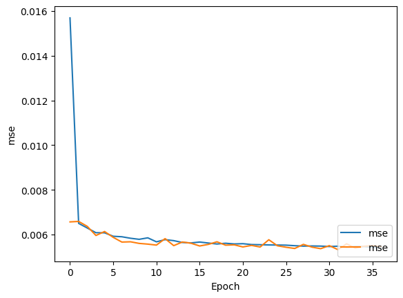

```python
# Resultats
plt.plot(history.history['mse'], label='mse')
plt.plot(history.history['val_mse'], label = 'mse')
plt.xlabel('Epoch')
plt.ylabel('mse')
#plt.ylim([0.0, 1])
plt.legend(loc='lower right')
# Validació al conjunt de prova
test_loss, test_acc = suprel.evaluate(val_sr_ds, verbose=2)
```

**Comentaris:**

## 6. Inferència, mètriques i visualització dels resultats (1 punt)

Amb el model de superresolució entrenat, avaluarem el seu rendiment tant quantitativament (amb mètriques) com qualitativament (visualització d’imatges). Per fer -ho, realitzarem la inferència: és a dir, prendre imatges LR del conjunt de test, passar-les pel model `sr_model` per obtenir imatges supers resoltes (SR) i comparar-les amb les imatges HR originals. Calcularem la mètrica [PSNR (Peak Signal-to-Notise Ratio)](https://es.wikipedia.org/wiki/psnr) per quantificar la qualitat.

El PSNR es mesura en decibels (dB) i els valors superiors indiquen una major similitud amb la imatge original (per exemple,> 30 dB sol indicar una qualitat de reconstrucció molt bona).

També visualitzarem alguns exemples, on mostraren la imatge de baixa resolució (LR), la super resolta per la CNN (SR) i l’original d’alta resolució (HR), per inspeccionar els detalls amb l’ull nu.

**Exercici 6 [1 pt]:** Realitza la inferència del model de superresolució sobre diverses imatges de test:

- Per a cada imatge de test, obté la seva versió de baixa resolució (LR) i genera la imatge superresolta (SR) amb el model.
- Calcula la mètrica PSNR comparant la imatge SR amb la HR original per a tot el conjunt de test.
- Mostra visualment alguns exemples, incloent-hi la imatge d'entrada LR (pots ampliar-la per mostrar-la de la mateixa mida utilitzant el mètode `tf.image.resize()` juntament amb `method=tf.image.ResizeMethod.NEAREST_NEIGHBOR`), la imatge generada pel model (SR) i la imatge HR original, per poder comparar la qualitat visualment a part del valor de la PSNR.

Comentar els resultats obtinguts:

- Quins valors de PSNR s’obtenen? (Comenta tant els exemples mostrats com el valor mitjà del total del conjunt de prova)
- Les imatges creades amb superresolució són nítides o borroses?
- Quins tipus de detalls o errors s’observen?

**Nota: es valorarà la concisió a les preguntes (una o dues frases són suficients per a cadascuna de les respostes).**

```python
test_classes = os.listdir(path + "/val")
test_dir =  Path("/kaggle/input/images/images/val")
# Preparar conjunt de test per a SR (a partir del directori /val )
import random
# Definir funcio que donada la ruta a una imatge retorna la imatge en alta i baixa resolucio
def preprocess_image_for_sr(filepath):
    # Lleixim la imatge a la ruta i la convertim en un tensor amb tres canals
    img = tf.io.read_file(filepath)
    img = tf.image.decode_jpeg(img, channels=3)
    # Transformem els valors del tensor a float32
    img = tf.image.convert_image_dtype(img, tf.float32)
    # utilitzant l'interpolació bicúbica redimiensionem la imatge a 320x320 i 80x80 respectivament
    hr = tf.image.resize(img, [320, 320], method=tf.image.ResizeMethod.BICUBIC)
    lr = tf.image.resize(img, [80, 80], method=tf.image.ResizeMethod.BICUBIC)
    # Normalitzem els valors dels tensors perque estiguin entre 0 i 1
    hr = tf.clip_by_value(hr, 0.0, 1.0)
    lr = tf.clip_by_value(lr, 0.0, 1.0)
    return lr, hr

# Definim dues llistes on guardarem els nom dels axiuis tant de tes com de train
test_files = []
for cls in test_classes:
    cls_files = sorted((test_dir/cls).glob("*.*"))
    test_files += [str(p) for p in cls_files]
random.shuffle(test_files)

# Generarem els datasets aplicalntli la funicio a tots els arxius paralelitzant en batches de 32
test_sr_ds = tf.data.Dataset.from_tensor_slices(test_files).map(preprocess_image_for_sr, num_parallel_calls=tf.data.AUTOTUNE).batch(32).prefetch(tf.data.AUTOTUNE)
```

```python
# Verificació d'un parell LR-HR
for lr_batch, hr_batch in test_sr_ds.take(1):
    lr_img = lr_batch[0].numpy()
    hr_img = hr_batch[0].numpy()
    print("LR shape:", lr_img.shape, "HR shape:", hr_img.shape)
    print("LR pixel range:", lr_img.min(), "-", lr_img.max())
    print("HR pixel range:", hr_img.min(), "-", hr_img.max())
    break
```

```
LR shape: (80, 80, 3) HR shape: (320, 320, 3)
LR pixel range: 0.0 - 1.0
HR pixel range: 0.0 - 1.0
```

```python
# Llista per emmagatzemar la PSNR de cada imatge
import contextlib
@contextlib.contextmanager
def suppress_stdout():
    with open(os.devnull, "w") as devnull:
        old_stdout = os.sys.stdout
        os.sys.stdout = devnull
        try:
            yield
        finally:
            os.sys.stdout = old_stdout

psnr_of_images = []
# Recórrer el dataset de test (batch size = 1)
for lr_batch, hr_batch in test_sr_ds.unbatch().batch(1).take(5):
    lr_img = lr_batch.numpy()
    hr_img = hr_batch.numpy()
    #print(lr_batch)
    # Generar la imatge de superresolució a partir de la imatge LR
    with suppress_stdout():
        hr_img_pred = suprel.predict(lr_img, batch_size=1)


 # Treure la dimensió de batch i assegurar que els valors estiguin a [0,1]


    print("LR shape:", lr_img.shape, "HR shape:", hr_img.shape, "HR_pred shape:", hr_img_pred.shape)
    #print("LR pixel range:", lr_img.min(), "-", lr_img.max())
    #print("HR pixel range:", hr_img.min(), "-", hr_img.max())
    print("HR_pred pixel range:", hr_img_pred.min(), "-", hr_img_pred.max())
for lr_batch, hr_batch in test_sr_ds.unbatch().batch(1):
    lr_img = lr_batch.numpy()
    hr_img = hr_batch.numpy()
    #print(lr_batch)
     # Generar la imatge de superresolució a partir de la imatge LR
    with suppress_stdout():
        hr_img_pred = suprel.predict(lr_img, batch_size=1)

 # Convertir la imatge HR a array de numpy (llevem la dimensió de batch)
    hr_img_pred = hr_img_pred[0]
 # Calcular la PSNR entre la imatge SR generada i la imatge HR original
    psnr_of_image = tf.image.psnr(hr_img,hr_img_pred,max_val=1.0)

 # Emmagatzemar el valor de PSNR a la llista
    psnr_of_images.append(psnr_of_image)

# Calcular la PSNR mitjana del conjunt de test
avg_psnr = np.mean(psnr_of_images)
print("PSNR mitjana al conjunt de test: {:.2f} dB".format(avg_psnr))
```

```
LR shape: (1, 80, 80, 3) HR shape: (1, 320, 320, 3) HR_pred shape: (1, 320, 320, 3)
HR_pred pixel range: 0.0 - 1.0
LR shape: (1, 80, 80, 3) HR shape: (1, 320, 320, 3) HR_pred shape: (1, 320, 320, 3)
HR_pred pixel range: 0.041284136 - 0.9868694
LR shape: (1, 80, 80, 3) HR shape: (1, 320, 320, 3) HR_pred shape: (1, 320, 320, 3)
HR_pred pixel range: 0.015057867 - 0.9594716
LR shape: (1, 80, 80, 3) HR shape: (1, 320, 320, 3) HR_pred shape: (1, 320, 320, 3)
HR_pred pixel range: 0.0 - 0.9418434
LR shape: (1, 80, 80, 3) HR shape: (1, 320, 320, 3) HR_pred shape: (1, 320, 320, 3)
HR_pred pixel range: 0.0 - 1.0
PSNR mitjana al conjunt de test: 23.78 dB
```